# Исследование объявлений о продаже квартир

### Предобработка данных

#### Начнём работы с пропусками

##### Определим в каких столбцах есть пропуски. Возьмём данные из таблицы data.info.

```python
to_fill = data.info()
```

```
<class 'pandas.core.frame.DataFrame'>
RangeIndex: 23699 entries, 0 to 23698
Data columns (total 22 columns):
 #   Column                Non-Null Count  Dtype
---  ------                --------------  -----
 0   total_images          23699 non-null  int64
 1   last_price            23699 non-null  float64
 2   total_area            23699 non-null  float64
 3   first_day_exposition  23699 non-null  object
 4   rooms                 23699 non-null  int64
 5   ceiling_height        14504 non-null  float64
 6   floors_total          23613 non-null  float64
 7   living_area           21796 non-null  float64
 8   floor                 23699 non-null  int64
 9   is_apartment          2775 non-null   object
 10  studio                23699 non-null  bool
 11  open_plan             23699 non-null  bool
 12  kitchen_area          21421 non-null  float64
 13  balcony               12180 non-null  float64
 14  locality_name         23650 non-null  object
 15  airports_nearest      18157 non-null  float64
 16  cityCenters_nearest   18180 non-null  float64
 17  parks_around3000      18181 non-null  float64
 18  parks_nearest         8079 non-null   float64
 19  ponds_around3000      18181 non-null  float64
 20  ponds_nearest         9110 non-null   float64
 21  days_exposition       20518 non-null  float64
dtypes: bool(2), float64(14), int64(3), object(3)
memory usage: 3.7+ MB
```

Оставим только те столбцы, в которых есть пропуски.

```python
try:
    to_fill = to_fill[to_fill['Non-Null'] != 23699]
except:
    print('Не получается\nЭх')
```

```
Не получается
Эх
```

Что ж. Тогда просто вручную запишем названия столбцов и количество имеющихся значений в них. Запомним, что всего в таблице 23699 строк.

Ой, а можете ещё даблкликнуть на следующий блок?

1 ceiling_height 14504 2 floors_total 23613 3 living_area 21796 4 is_apartment 2775 5 kitchen_area 21421 6 balcony 12180 7 locality_name 23650 8 airports_nearest 18157 9 cityCenters_nearest 18180 10 parks_around3000 18181 11 parks_nearest 8079 12 ponds_around3000 18181 13 ponds_nearest 9110 14 days_exposition 20518

14 из 22. Не унываем! Если в сыре много дыр - значит, вкусным будет сыр! В конце концов нам платят за рабочие часы. Платят же?

Немного поплакали и можно возвращаться к работе. Начнём заполнять пропуски.

Больше всего пропусков в столбце is_apartment, там всего 2775 значений. Чем больше шкаф, тем громче падает. Попробуем разобраться, что к чему.

Обратимся к легенде. is_apartment — апартаменты (булев тип). Получается, тут содержится информация о том, является ли жилплощадь апартаментами или нет. Посмотрим на данные.

```python
data['is_apartment'].value_counts()
```

```
False    2725
True       50
Name: is_apartment, dtype: int64
```

Гмм. Нуууу. Я ожидал, что все или почти все значения окажутся True и можно будет сделать вывод, что пропуски связаны с тем, что для обычных квартир этот параметр просто не был указан.

Вряд ли на 23699 объявлений было всего 50 апартаментов. Вероятно, данные для этого пункта взяты из отдельной площадки для объявлений или просто были необязательными для заполнения.

Не думаю, что есть смысл пытаться заполнить этот столбец. Давайте просто избавимся от него.

P.S. Если бы мне приставили пистолет ко лбу и сказали, что мне необходимо провести анализ и по этому параметру, то можно было бы сделать отдельный срез данных по этому столбцу и провести сравнение по тому, что имеем. Но учитывая, что в группе 'True' всего 50 значений, а у нас куча других параметров, влияющих на ценообразование, скорее всего мы бы не смогли оценить, даже то, насколько это значение влияет на итоговую цену.

```python
data.drop('is_apartment', axis=1, inplace=True)
```

Извини, 'is_apartment', тебе не повезло. Ты, наверно, думаешь, что тебе выпало 18 карат невезения? Да нет, просто игра попалась нечестная.

Проверим, всё ли мы сделали правильно.

```python
data.info()
```

```
<class 'pandas.core.frame.DataFrame'>
RangeIndex: 23699 entries, 0 to 23698
Data columns (total 21 columns):
 #   Column                Non-Null Count  Dtype
---  ------                --------------  -----
 0   total_images          23699 non-null  int64
 1   last_price            23699 non-null  float64
 2   total_area            23699 non-null  float64
 3   first_day_exposition  23699 non-null  object
 4   rooms                 23699 non-null  int64
 5   ceiling_height        14504 non-null  float64
 6   floors_total          23613 non-null  float64
 7   living_area           21796 non-null  float64
 8   floor                 23699 non-null  int64
 9   studio                23699 non-null  bool
 10  open_plan             23699 non-null  bool
 11  kitchen_area          21421 non-null  float64
 12  balcony               12180 non-null  float64
 13  locality_name         23650 non-null  object
 14  airports_nearest      18157 non-null  float64
 15  cityCenters_nearest   18180 non-null  float64
 16  parks_around3000      18181 non-null  float64
 17  parks_nearest         8079 non-null   float64
 18  ponds_around3000      18181 non-null  float64
 19  ponds_nearest         9110 non-null   float64
 20  days_exposition       20518 non-null  float64
dtypes: bool(2), float64(14), int64(3), object(2)
memory usage: 3.5+ MB
```

Отлично. Теперь посмотрим, что там с balcony (число балконов).

```python
data['balcony'].value_counts()
```

```
1.0    4195
0.0    3758
2.0    3659
5.0     304
4.0     183
3.0      81
Name: balcony, dtype: int64
```

Денис не согласен, но в задании сказано, что если не указано число балконов, то их скорее всего 0, и нужно так и заполнить. Сказано - сделано!

```python
data['balcony'] = data['balcony'].fillna(0)
data['balcony'].value_counts()
```

```
0.0    15277
1.0     4195
2.0     3659
5.0      304
4.0      183
3.0       81
Name: balcony, dtype: int64
```

Кто на новенького?

В locality_name (название населенного пункта) не хватает всего 49 значений. Посмотрим, что это за строки и можно ли их заполнить.

```python
data[data['locality_name'].isna() == True]
```

|  | total_images | last_price | total_area | first_day_exposition | rooms | ceiling_height | floors_total | living_area | floor | studio | ... | kitchen_area | balcony | locality_name | airports_nearest | cityCenters_nearest | parks_around3000 | parks_nearest | ponds_around3000 | ponds_nearest | days_exposition |
| --- | --- | --- | --- | --- | --- | --- | --- | --- | --- | --- | --- | --- | --- | --- | --- | --- | --- | --- | --- | --- | --- |
| 1097 | 3 | 8600000.0 | 81.70 | 2016-04-15T00:00:00 | 3 | 3.55 | 5.0 | 50.80 | 2 | False | ... | 8.80 | 0.0 | NaN | 23478.0 | 4258.0 | 0.0 | NaN | 0.0 | NaN | 147.0 |
| 2033 | 6 | 5398000.0 | 80.00 | 2017-05-30T00:00:00 | 3 | NaN | 4.0 | 42.60 | 2 | False | ... | 18.60 | 0.0 | NaN | NaN | NaN | NaN | NaN | NaN | NaN | 34.0 |
| 2603 | 20 | 3351765.0 | 42.70 | 2015-09-20T00:00:00 | 1 | NaN | 24.0 | 15.60 | 3 | False | ... | 10.70 | 0.0 | NaN | 22041.0 | 17369.0 | 0.0 | NaN | 1.0 | 374.0 | 276.0 |
| 2632 | 2 | 5130593.0 | 62.40 | 2015-10-11T00:00:00 | 2 | NaN | 24.0 | 33.10 | 21 | False | ... | 8.20 | 0.0 | NaN | 22041.0 | 17369.0 | 0.0 | NaN | 1.0 | 374.0 | 256.0 |
| 3574 | 10 | 4200000.0 | 46.50 | 2016-05-28T00:00:00 | 2 | NaN | 5.0 | 30.80 | 5 | False | ... | 6.50 | 0.0 | NaN | 27419.0 | 8127.0 | 0.0 | NaN | 1.0 | 603.0 | 45.0 |
| 4151 | 17 | 17600000.0 | 89.50 | 2014-12-09T00:00:00 | 2 | 3.00 | 8.0 | 39.62 | 7 | False | ... | 13.38 | 0.0 | NaN | 25054.0 | 3902.0 | 1.0 | 485.0 | 3.0 | 722.0 | 869.0 |
| 4189 | 7 | 9200000.0 | 80.00 | 2015-12-10T00:00:00 | 3 | 4.00 | 4.0 | 52.30 | 3 | False | ... | 10.40 | 0.0 | NaN | 21774.0 | 3039.0 | 1.0 | 690.0 | 1.0 | 953.0 | 223.0 |
| 4670 | 1 | 5500000.0 | 83.00 | 2015-08-14T00:00:00 | 3 | NaN | 7.0 | NaN | 6 | False | ... | NaN | 0.0 | NaN | 26534.0 | 5382.0 | 1.0 | 446.0 | 1.0 | 376.0 | 350.0 |
| 5343 | 19 | 13540000.0 | 85.50 | 2016-01-20T00:00:00 | 3 | NaN | 7.0 | 59.10 | 5 | False | ... | 8.30 | 4.0 | NaN | 10556.0 | 9538.0 | 1.0 | 67.0 | 0.0 | NaN | 303.0 |
| 5707 | 7 | 3700000.0 | 30.00 | 2016-04-29T00:00:00 | 1 | NaN | 24.0 | 20.00 | 23 | False | ... | NaN | 0.0 | NaN | 21460.0 | 16788.0 | 0.0 | NaN | 1.0 | 170.0 | 49.0 |
| 6765 | 20 | 4895892.0 | 60.70 | 2015-03-12T00:00:00 | 2 | NaN | 24.0 | 31.90 | 3 | False | ... | 12.20 | 0.0 | NaN | 22041.0 | 17369.0 | 0.0 | NaN | 1.0 | 374.0 | 468.0 |
| 7114 | 5 | 4250000.0 | 56.00 | 2016-03-16T00:00:00 | 3 | NaN | 5.0 | 40.00 | 4 | False | ... | 6.00 | 0.0 | NaN | 14031.0 | 8582.0 | 0.0 | NaN | 0.0 | NaN | 96.0 |
| 7330 | 8 | 5100000.0 | 63.00 | 2015-01-27T00:00:00 | 3 | NaN | 5.0 | 42.00 | 1 | False | ... | 7.50 | 0.0 | NaN | 25925.0 | 4627.0 | 2.0 | 459.0 | 0.0 | NaN | 566.0 |
| 7600 | 8 | 6800000.0 | 70.00 | 2016-01-31T00:00:00 | 3 | NaN | 11.0 | 42.00 | 9 | False | ... | 11.00 | 1.0 | NaN | 37123.0 | 12332.0 | 0.0 | NaN | 0.0 | NaN | 209.0 |
| 8568 | 10 | 16000000.0 | 155.00 | 2016-05-09T00:00:00 | 3 | NaN | 6.0 | 94.00 | 3 | False | ... | 23.00 | 0.0 | NaN | 24233.0 | 4065.0 | 1.0 | 547.0 | 0.0 | NaN | 248.0 |
| 8986 | 10 | 4850000.0 | 103.10 | 2018-07-10T00:00:00 | 3 | NaN | NaN | 68.10 | 4 | False | ... | 16.70 | 0.0 | NaN | 19659.0 | 31813.0 | 0.0 | NaN | 0.0 | NaN | 28.0 |
| 9821 | 13 | 8000000.0 | 94.50 | 2015-01-21T00:00:00 | 4 | 3.00 | 2.0 | 57.80 | 2 | False | ... | 11.30 | 0.0 | NaN | 24953.0 | 3801.0 | 1.0 | 375.0 | 2.0 | 532.0 | 531.0 |
| 10122 | 5 | 8200000.0 | 83.00 | 2015-06-24T00:00:00 | 4 | NaN | 5.0 | 53.00 | 2 | False | ... | 10.00 | 0.0 | NaN | 25771.0 | 4474.0 | 2.0 | 374.0 | 0.0 | NaN | 364.0 |
| 11248 | 12 | 6300000.0 | 63.10 | 2015-01-16T00:00:00 | 4 | NaN | 8.0 | 44.00 | 7 | False | ... | 8.70 | 0.0 | NaN | 25221.0 | 4069.0 | 0.0 | NaN | 2.0 | 653.0 | 551.0 |
| 12879 | 12 | 4400000.0 | 39.20 | 2016-04-26T00:00:00 | 1 | NaN | 12.0 | 20.00 | 12 | False | ... | 7.90 | 0.0 | NaN | 37123.0 | 12332.0 | 0.0 | NaN | 0.0 | NaN | 179.0 |
| 12936 | 6 | 6800000.0 | 73.00 | 2015-11-01T00:00:00 | 3 | NaN | 5.0 | 53.10 | 2 | False | ... | 8.20 | 0.0 | NaN | 25680.0 | 4383.0 | 3.0 | 336.0 | 0.0 | NaN | 542.0 |
| 13223 | 1 | 2919911.0 | 29.40 | 2015-03-12T00:00:00 | 1 | 2.75 | 24.0 | 21.10 | 2 | False | ... | NaN | 0.0 | NaN | 22041.0 | 17369.0 | 0.0 | NaN | 1.0 | 374.0 | 470.0 |
| 13690 | 7 | 3500000.0 | 71.00 | 2016-06-23T00:00:00 | 3 | 2.75 | 2.0 | 45.60 | 1 | False | ... | 8.00 | 2.0 | NaN | 20234.0 | 23659.0 | 0.0 | NaN | 2.0 | 296.0 | 92.0 |
| 14273 | 2 | 4422000.0 | 60.00 | 2016-03-23T00:00:00 | 2 | 2.75 | 23.0 | 32.00 | 14 | False | ... | 11.90 | 0.0 | NaN | 22041.0 | 17369.0 | 0.0 | NaN | 1.0 | 374.0 | 90.0 |
| 14342 | 3 | 3611000.0 | 53.50 | 2017-04-27T00:00:00 | 1 | NaN | 4.0 | 25.80 | 3 | False | ... | NaN | 1.0 | NaN | NaN | NaN | NaN | NaN | NaN | NaN | 92.0 |
| 15686 | 13 | 4700000.0 | 44.00 | 2015-12-01T00:00:00 | 2 | NaN | 5.0 | 28.00 | 3 | False | ... | 5.00 | 0.0 | NaN | 35920.0 | 9633.0 | 2.0 | 472.0 | 3.0 | 535.0 | 280.0 |
| 15866 | 10 | 3950000.0 | 44.00 | 2016-04-16T00:00:00 | 2 | 2.70 | 5.0 | 28.50 | 5 | False | ... | 5.50 | 1.0 | NaN | 36380.0 | 9497.0 | 1.0 | 634.0 | 3.0 | 513.0 | 85.0 |
| 16499 | 2 | 4995573.0 | 56.90 | 2016-06-17T00:00:00 | 2 | NaN | 24.0 | 29.20 | 14 | False | ... | 10.90 | 0.0 | NaN | 22041.0 | 17369.0 | 0.0 | NaN | 1.0 | 374.0 | 4.0 |
| 16561 | 3 | 2450000.0 | 30.00 | 2016-06-02T00:00:00 | 1 | NaN | 4.0 | 17.00 | 2 | False | ... | 6.00 | 1.0 | NaN | 21731.0 | 8619.0 | 0.0 | NaN | 3.0 | 162.0 | 140.0 |
| 16610 | 11 | 11940000.0 | 112.00 | 2015-11-19T00:00:00 | 3 | 3.00 | 5.0 | 64.00 | 2 | False | ... | 23.00 | 0.0 | NaN | 21219.0 | 1322.0 | 1.0 | 740.0 | 3.0 | 365.0 | 319.0 |
| 17535 | 2 | 5985000.0 | 79.80 | 2018-07-30T00:00:00 | 3 | NaN | 9.0 | NaN | 2 | False | ... | NaN | 0.0 | NaN | NaN | NaN | NaN | NaN | NaN | NaN | 213.0 |
| 17764 | 9 | 8400000.0 | 94.00 | 2016-01-24T00:00:00 | 3 | NaN | 23.0 | 52.00 | 5 | False | ... | NaN | 0.0 | NaN | 36865.0 | 10976.0 | 0.0 | NaN | 1.0 | 856.0 | 305.0 |
| 18526 | 3 | 10800000.0 | 86.00 | 2016-06-24T00:00:00 | 4 | 3.20 | 7.0 | 48.00 | 2 | False | ... | 12.00 | 0.0 | NaN | 11206.0 | 8943.0 | 0.0 | NaN | 0.0 | NaN | 65.0 |
| 18917 | 3 | 2660000.0 | 37.99 | 2017-08-17T00:00:00 | 1 | NaN | 4.0 | 13.00 | 1 | False | ... | 12.40 | 0.0 | NaN | 21540.0 | 8429.0 | 0.0 | NaN | 3.0 | 142.0 | 15.0 |
| 19045 | 6 | 4650000.0 | 48.00 | 2016-01-25T00:00:00 | 2 | 3.12 | 5.0 | 26.20 | 1 | False | ... | 8.00 | 0.0 | NaN | 21654.0 | 3312.0 | 1.0 | 549.0 | 1.0 | 858.0 | 254.0 |
| 19972 | 20 | 4361004.0 | 62.40 | 2015-09-20T00:00:00 | 2 | NaN | 24.0 | 33.10 | 21 | False | ... | 8.20 | 0.0 | NaN | 22041.0 | 17369.0 | 0.0 | NaN | 1.0 | 374.0 | 278.0 |
| 20057 | 13 | 11500000.0 | 102.00 | 2015-10-14T00:00:00 | 2 | NaN | 5.0 | 70.00 | 2 | False | ... | NaN | 0.0 | NaN | 23478.0 | 4258.0 | 0.0 | NaN | 0.0 | NaN | 325.0 |
| 20382 | 8 | 1750000.0 | 72.90 | 2018-10-27T00:00:00 | 3 | NaN | 5.0 | 47.30 | 2 | False | ... | 8.30 | 0.0 | NaN | NaN | NaN | NaN | NaN | NaN | NaN | NaN |
| 20590 | 7 | 3380000.0 | 56.00 | 2017-11-06T00:00:00 | 2 | 2.70 | 4.0 | 29.00 | 3 | False | ... | 10.00 | 1.0 | NaN | NaN | NaN | NaN | NaN | NaN | NaN | 78.0 |
| 20654 | 7 | 6100000.0 | 43.00 | 2016-01-13T00:00:00 | 1 | NaN | 5.0 | 21.00 | 3 | False | ... | 12.00 | 1.0 | NaN | 24385.0 | 4604.0 | 1.0 | 700.0 | 0.0 | NaN | 164.0 |
| 21119 | 8 | 3500000.0 | 43.20 | 2018-11-11T00:00:00 | 2 | NaN | 4.0 | NaN | 2 | False | ... | NaN | 0.0 | NaN | 19744.0 | 31897.0 | 0.0 | NaN | 0.0 | NaN | 9.0 |
| 21276 | 0 | 17122148.0 | 178.30 | 2017-02-10T00:00:00 | 1 | NaN | 3.0 | NaN | 1 | False | ... | 41.60 | 1.0 | NaN | 60195.0 | 41294.0 | 0.0 | NaN | 0.0 | NaN | 4.0 |
| 21333 | 10 | 5900000.0 | 58.00 | 2015-03-12T00:00:00 | 3 | NaN | 6.0 | 35.20 | 6 | False | ... | 11.00 | 0.0 | NaN | 26090.0 | 4805.0 | 0.0 | NaN | 1.0 | 943.0 | 486.0 |
| 21715 | 2 | 6047550.0 | 80.10 | 2018-07-30T00:00:00 | 2 | NaN | 9.0 | 30.50 | 2 | False | ... | 29.20 | 0.0 | NaN | NaN | NaN | NaN | NaN | NaN | NaN | 176.0 |
| 21898 | 2 | 5886750.0 | 83.50 | 2018-07-30T00:00:00 | 2 | NaN | 9.0 | 36.60 | 2 | False | ... | 29.70 | 0.0 | NaN | NaN | NaN | NaN | NaN | NaN | NaN | 169.0 |
| 22474 | 7 | 24000000.0 | 128.00 | 2015-07-24T00:00:00 | 4 | 2.75 | 6.0 | 68.40 | 6 | False | ... | 16.50 | 0.0 | NaN | 23297.0 | 1780.0 | 3.0 | 277.0 | 3.0 | 561.0 | 436.0 |
| 22717 | 9 | 3000000.0 | 35.00 | 2018-01-02T00:00:00 | 1 | 2.60 | 16.0 | 16.00 | 7 | False | ... | 10.00 | 1.0 | NaN | NaN | NaN | NaN | NaN | NaN | NaN | 75.0 |
| 22933 | 20 | 3176015.0 | 33.30 | 2015-04-22T00:00:00 | 1 | NaN | 23.0 | 15.40 | 22 | False | ... | 9.00 | 0.0 | NaN | 22041.0 | 17369.0 | 0.0 | NaN | 1.0 | 374.0 | 427.0 |
| 23214 | 3 | 7990000.0 | 56.00 | 2016-05-31T00:00:00 | 2 | NaN | 6.0 | NaN | 5 | False | ... | NaN | 0.0 | NaN | 11206.0 | 8943.0 | 0.0 | NaN | 0.0 | NaN | 70.0 |

49 rows × 21 columns

Посмотрим на last_price и total_area.

Алиса, какая была средняя цена за кв.м в питере в 2019 году?

Если коротко, то говорит, что около 115 000. Похоже на правду, видимо, это Дефолт-Сити 2.

Проверим, как в данных обозначен Санкт-Петербург.

```python
data['locality_name'].value_counts()
```

```
Санкт-Петербург                               15721
посёлок Мурино                                  522
посёлок Шушары                                  440
Всеволожск                                      398
Пушкин                                          369
                                              ...
деревня Чудской Бор                               1
посёлок при железнодорожной станции Вещево        1
посёлок Шугозеро                                  1
коттеджный поселок Счастье                        1
поселок Перово                                    1
Name: locality_name, Length: 364, dtype: int64
```

Разумно. Заполним пропуски и проверим результат.

```python
data['locality_name'] = data['locality_name'].fillna('Санкт-Петербург')
data['locality_name'].value_counts()
```

```
Санкт-Петербург                               15770
посёлок Мурино                                  522
посёлок Шушары                                  440
Всеволожск                                      398
Пушкин                                          369
                                              ...
деревня Чудской Бор                               1
посёлок при железнодорожной станции Вещево        1
посёлок Шугозеро                                  1
коттеджный поселок Счастье                        1
поселок Перово                                    1
Name: locality_name, Length: 364, dtype: int64
```

Да я сегодня в ударе! Продолжим.

Заполним пропуски в city_center (расстояние до центра города в метрах). Там всего 18180 значений. Для начала посмотрим, какие названия населённых пунктов встречаются в пропущенных строках.

```python
center_range = data.loc[data['cityCenters_nearest'].isna() == True]
center_range['locality_name'].value_counts().head(20)
```

```
посёлок Мурино             522
Всеволожск                 398
Гатчина                    307
деревня Кудрово            299
Выборг                     237
Кудрово                    173
деревня Новое Девяткино    144
Сертолово                  142
Кириши                     125
Сланцы                     112
Волхов                     111
Тосно                      104
Кингисепп                  104
Никольское                  93
Коммунар                    89
Сосновый Бор                87
Кировск                     84
Отрадное                    80
посёлок Бугры               69
Санкт-Петербург             69
Name: locality_name, dtype: int64
```

Здесь я пропал из проектной работы почти на месяц. Я регулярно возвращался, но каждый раз не мог заставить себя просидеть достаточно долго, чтобы сдвинуться с мёртвой точки и реализовать сложное решение для этого столбца и floors_total. И не был готов использовать простое. Попробуем ещё раз сделать всё хорошо.

```python
center_range['locality_name'].value_counts().head(40)
```

```
посёлок Мурино                             522
Всеволожск                                 398
Гатчина                                    307
деревня Кудрово                            299
Выборг                                     237
Кудрово                                    173
деревня Новое Девяткино                    144
Сертолово                                  142
Кириши                                     125
Сланцы                                     112
Волхов                                     111
Тосно                                      104
Кингисепп                                  104
Никольское                                  93
Коммунар                                    89
Сосновый Бор                                87
Кировск                                     84
Отрадное                                    80
посёлок Бугры                               69
Санкт-Петербург                             69
Приозерск                                   66
деревня Старая                              64
городской посёлок Янино-1                   61
Шлиссельбург                                57
Луга                                        56
Тихвин                                      49
поселок Бугры                               45
посёлок Тельмана                            39
Волосово                                    36
поселок Романовка                           36
Мурино                                      34
поселок Мурино                              32
посёлок городского типа Сиверский           29
Ивангород                                   28
городской посёлок Новоселье                 28
городской посёлок Мга                       27
поселок городского типа имени Свердлова     25
Сясьстрой                                   24
посёлок Щеглово                             22
посёлок городского типа Кузьмоловский       22
Name: locality_name, dtype: int64
```

Очень много деревень и посёлков. Посмотрим, сколько вообще по ним строк с данными.

```python
data['locality_name'].value_counts().head(40)
```

```
Санкт-Петербург              15770
посёлок Мурино                 522
посёлок Шушары                 440
Всеволожск                     398
Пушкин                         369
Колпино                        338
посёлок Парголово              327
Гатчина                        307
деревня Кудрово                299
Выборг                         237
Петергоф                       201
Сестрорецк                     183
Красное Село                   178
Кудрово                        173
деревня Новое Девяткино        144
Сертолово                      142
Ломоносов                      133
Кириши                         125
Сланцы                         112
Волхов                         111
Тосно                          104
Кингисепп                      104
Кронштадт                       96
Никольское                      93
Коммунар                        89
Сосновый Бор                    87
Кировск                         84
Отрадное                        80
посёлок Бугры                   69
посёлок Металлострой            66
Приозерск                       66
деревня Старая                  64
городской посёлок Янино-1       61
Шлиссельбург                    57
Луга                            56
Тихвин                          49
поселок Бугры                   45
посёлок Стрельна                44
посёлок Тельмана                39
Павловск                        38
Name: locality_name, dtype: int64
```

Большинство пропусков соответствуют деревням, посёлкам и т.п. Cкорее всего алгоритму просто не сказали, что для них нужно считать расстояние до центра. Мы не можем их заполнить, да и не считаем нужным. Но есть и пропуски в городах. Пока непонятно, с чем они связаны. Давайте посмотрим, сколько пропусков у нас в Питере.

```python
center_spb = center_range[center_range['locality_name'] == 'Санкт-Петербург']
center_spb.info()
```

```
<class 'pandas.core.frame.DataFrame'>
Int64Index: 69 entries, 81 to 22717
Data columns (total 21 columns):
 #   Column                Non-Null Count  Dtype
---  ------                --------------  -----
 0   total_images          69 non-null     int64
 1   last_price            69 non-null     float64
 2   total_area            69 non-null     float64
 3   first_day_exposition  69 non-null     object
 4   rooms                 69 non-null     int64
 5   ceiling_height        33 non-null     float64
 6   floors_total          68 non-null     float64
 7   living_area           52 non-null     float64
 8   floor                 69 non-null     int64
 9   studio                69 non-null     bool
 10  open_plan             69 non-null     bool
 11  kitchen_area          51 non-null     float64
 12  balcony               69 non-null     float64
 13  locality_name         69 non-null     object
 14  airports_nearest      0 non-null      float64
 15  cityCenters_nearest   0 non-null      float64
 16  parks_around3000      0 non-null      float64
 17  parks_nearest         0 non-null      float64
 18  ponds_around3000      0 non-null      float64
 19  ponds_nearest         0 non-null      float64
 20  days_exposition       32 non-null     float64
dtypes: bool(2), float64(14), int64(3), object(2)
memory usage: 10.9+ KB
```

Всего 69. Удивительно малая доля для самого популярного города. Посмотрим внимательнее на этот срез.

```python
center_spb
```

|  | total_images | last_price | total_area | first_day_exposition | rooms | ceiling_height | floors_total | living_area | floor | studio | ... | kitchen_area | balcony | locality_name | airports_nearest | cityCenters_nearest | parks_around3000 | parks_nearest | ponds_around3000 | ponds_nearest | days_exposition |
| --- | --- | --- | --- | --- | --- | --- | --- | --- | --- | --- | --- | --- | --- | --- | --- | --- | --- | --- | --- | --- | --- |
| 81 | 9 | 10949000.0 | 68.00 | 2018-12-27T00:00:00 | 1 | NaN | 10.0 | NaN | 6 | False | ... | NaN | 0.0 | Санкт-Петербург | NaN | NaN | NaN | NaN | NaN | NaN | NaN |
| 593 | 20 | 4200000.0 | 38.30 | 2019-04-16T00:00:00 | 1 | 2.6 | 16.0 | 19.8 | 10 | False | ... | 10.1 | 2.0 | Санкт-Петербург | NaN | NaN | NaN | NaN | NaN | NaN | NaN |
| 604 | 11 | 9899000.0 | 101.00 | 2018-12-12T00:00:00 | 3 | 3.0 | 5.0 | 62.0 | 3 | False | ... | 15.0 | 0.0 | Санкт-Петербург | NaN | NaN | NaN | NaN | NaN | NaN | NaN |
| 742 | 7 | 37000000.0 | 161.00 | 2016-05-22T00:00:00 | 3 | NaN | 9.0 | 84.0 | 8 | False | ... | NaN | 0.0 | Санкт-Петербург | NaN | NaN | NaN | NaN | NaN | NaN | 402.0 |
| 795 | 19 | 7100000.0 | 59.60 | 2019-02-13T00:00:00 | 2 | 3.4 | 5.0 | 36.6 | 2 | False | ... | 12.5 | 0.0 | Санкт-Петербург | NaN | NaN | NaN | NaN | NaN | NaN | NaN |
| ... | ... | ... | ... | ... | ... | ... | ... | ... | ... | ... | ... | ... | ... | ... | ... | ... | ... | ... | ... | ... | ... |
| 21898 | 2 | 5886750.0 | 83.50 | 2018-07-30T00:00:00 | 2 | NaN | 9.0 | 36.6 | 2 | False | ... | 29.7 | 0.0 | Санкт-Петербург | NaN | NaN | NaN | NaN | NaN | NaN | 169.0 |
| 21955 | 19 | 130000000.0 | 431.00 | 2017-10-02T00:00:00 | 7 | 3.7 | 8.0 | 220.0 | 5 | False | ... | 20.0 | 5.0 | Санкт-Петербург | NaN | NaN | NaN | NaN | NaN | NaN | 161.0 |
| 22554 | 5 | 3415000.0 | 31.65 | 2019-04-16T00:00:00 | 1 | NaN | 24.0 | NaN | 14 | False | ... | 8.7 | 2.0 | Санкт-Петербург | NaN | NaN | NaN | NaN | NaN | NaN | NaN |
| 22628 | 8 | 8600000.0 | 74.90 | 2019-03-14T00:00:00 | 3 | 3.0 | 5.0 | 53.2 | 4 | False | ... | 8.0 | 1.0 | Санкт-Петербург | NaN | NaN | NaN | NaN | NaN | NaN | NaN |
| 22717 | 9 | 3000000.0 | 35.00 | 2018-01-02T00:00:00 | 1 | 2.6 | 16.0 | 16.0 | 7 | False | ... | 10.0 | 1.0 | Санкт-Петербург | NaN | NaN | NaN | NaN | NaN | NaN | 75.0 |

69 rows × 21 columns

Пёс его знает, откуда взяли эти пропуски. Количество этажей разное. Стоимость тоже сильно разная, как и её отношение к площади, так что мою идею с тем, что это дом, который попал в 0 метров до центра следует отвергнуть. Как и идею, что район новоприсоединённый, и его в геосервисе забыли пометить как Питер. Моё лучшее предположение - пользователь указал город неправильно и геосервис выдал ошибку в расстоянии до центра.

Давайте заполнять. Для начала проверим, есть ли в строках с пропусками другие показатели расстояния.

```python
center_range
```

|  | total_images | last_price | total_area | first_day_exposition | rooms | ceiling_height | floors_total | living_area | floor | studio | ... | kitchen_area | balcony | locality_name | airports_nearest | cityCenters_nearest | parks_around3000 | parks_nearest | ponds_around3000 | ponds_nearest | days_exposition |
| --- | --- | --- | --- | --- | --- | --- | --- | --- | --- | --- | --- | --- | --- | --- | --- | --- | --- | --- | --- | --- | --- |
| 5 | 10 | 2890000.0 | 30.40 | 2018-09-10T00:00:00 | 1 | NaN | 12.0 | 14.40 | 5 | False | ... | 9.10 | 0.0 | городской посёлок Янино-1 | NaN | NaN | NaN | NaN | NaN | NaN | 55.0 |
| 8 | 20 | 2900000.0 | 33.16 | 2018-05-23T00:00:00 | 1 | NaN | 27.0 | 15.43 | 26 | False | ... | 8.81 | 0.0 | посёлок Мурино | NaN | NaN | NaN | NaN | NaN | NaN | 189.0 |
| 12 | 10 | 3890000.0 | 54.00 | 2016-06-30T00:00:00 | 2 | NaN | 5.0 | 30.00 | 5 | False | ... | 9.00 | 0.0 | Сертолово | NaN | NaN | NaN | NaN | NaN | NaN | 90.0 |
| 22 | 20 | 5000000.0 | 58.00 | 2017-04-24T00:00:00 | 2 | 2.75 | 25.0 | 30.00 | 15 | False | ... | 11.00 | 2.0 | деревня Кудрово | NaN | NaN | NaN | NaN | NaN | NaN | 60.0 |
| 30 | 12 | 2200000.0 | 32.80 | 2018-02-19T00:00:00 | 1 | NaN | 9.0 | NaN | 2 | False | ... | NaN | 0.0 | Коммунар | NaN | NaN | NaN | NaN | NaN | NaN | 63.0 |
| ... | ... | ... | ... | ... | ... | ... | ... | ... | ... | ... | ... | ... | ... | ... | ... | ... | ... | ... | ... | ... | ... |
| 23683 | 16 | 2100000.0 | 62.80 | 2018-09-18T00:00:00 | 4 | 2.50 | 5.0 | 45.50 | 3 | False | ... | 5.50 | 0.0 | посёлок Дзержинского | NaN | NaN | NaN | NaN | NaN | NaN | NaN |
| 23692 | 2 | 1350000.0 | 30.00 | 2017-07-07T00:00:00 | 1 | NaN | 5.0 | 17.50 | 4 | False | ... | 6.00 | 0.0 | Тихвин | NaN | NaN | NaN | NaN | NaN | NaN | 413.0 |
| 23695 | 14 | 3100000.0 | 59.00 | 2018-01-15T00:00:00 | 3 | NaN | 5.0 | 38.00 | 4 | False | ... | 8.50 | 0.0 | Тосно | NaN | NaN | NaN | NaN | NaN | NaN | 45.0 |
| 23696 | 18 | 2500000.0 | 56.70 | 2018-02-11T00:00:00 | 2 | NaN | 3.0 | 29.70 | 1 | False | ... | NaN | 0.0 | село Рождествено | NaN | NaN | NaN | NaN | NaN | NaN | NaN |
| 23698 | 4 | 1350000.0 | 32.30 | 2017-07-21T00:00:00 | 1 | 2.50 | 5.0 | 12.30 | 1 | False | ... | 9.00 | 0.0 | поселок Новый Учхоз | NaN | NaN | NaN | NaN | NaN | NaN | NaN |

5519 rows × 21 columns

Везде всё по нулям. Нет, знаете... Я честно пытался. И я решил сдаться. Это явно не будет критичным для наших будущих рассчётов. Давайте просто заполним пропуски значением -1 и пойдём дальше.

```python
data['cityCenters_nearest'].fillna(-1, inplace=True)
```

```python
data['cityCenters_nearest'].isna().sum()
```

```
0
```

Заполнили, проверили, осталось только прожить все стадии горя.

В floors_total (кол-во этажей в доме) 23613 значений. Пропусков мало. Сначала взглянем поближе.

```python
data[data['floors_total'].isna() == True]
```

|  | total_images | last_price | total_area | first_day_exposition | rooms | ceiling_height | floors_total | living_area | floor | studio | ... | kitchen_area | balcony | locality_name | airports_nearest | cityCenters_nearest | parks_around3000 | parks_nearest | ponds_around3000 | ponds_nearest | days_exposition |
| --- | --- | --- | --- | --- | --- | --- | --- | --- | --- | --- | --- | --- | --- | --- | --- | --- | --- | --- | --- | --- | --- |
| 186 | 12 | 11640000.0 | 65.2 | 2018-10-02T00:00:00 | 2 | NaN | NaN | 30.80 | 4 | False | ... | 12.00 | 0.0 | Санкт-Петербург | 39197.0 | 12373.0 | 1.0 | 123.0 | 0.0 | NaN | 49.0 |
| 237 | 4 | 2438033.0 | 28.1 | 2016-11-23T00:00:00 | 1 | NaN | NaN | 20.75 | 1 | False | ... | NaN | 0.0 | Санкт-Петербург | 22041.0 | 17369.0 | 0.0 | NaN | 1.0 | 374.0 | 251.0 |
| 457 | 4 | 9788348.0 | 70.8 | 2015-08-01T00:00:00 | 2 | NaN | NaN | 38.40 | 12 | False | ... | 10.63 | 0.0 | Санкт-Петербург | 37364.0 | 8322.0 | 2.0 | 309.0 | 2.0 | 706.0 | 727.0 |
| 671 | 4 | 6051191.0 | 93.6 | 2017-04-06T00:00:00 | 3 | NaN | NaN | 47.10 | 8 | False | ... | 16.80 | 0.0 | Санкт-Петербург | 22041.0 | 17369.0 | 0.0 | NaN | 1.0 | 374.0 | 123.0 |
| 1757 | 5 | 3600000.0 | 39.0 | 2017-04-22T00:00:00 | 1 | NaN | NaN | NaN | 9 | False | ... | NaN | 0.0 | Санкт-Петербург | 22735.0 | 11618.0 | 1.0 | 835.0 | 1.0 | 652.0 | 77.0 |
| ... | ... | ... | ... | ... | ... | ... | ... | ... | ... | ... | ... | ... | ... | ... | ... | ... | ... | ... | ... | ... | ... |
| 22542 | 5 | 8500000.0 | 63.5 | 2017-05-24T00:00:00 | 2 | 2.8 | NaN | NaN | 3 | False | ... | NaN | 0.0 | Санкт-Петербург | 51340.0 | 15363.0 | 0.0 | NaN | 1.0 | 853.0 | 512.0 |
| 22656 | 4 | 4574160.0 | 64.5 | 2017-04-02T00:00:00 | 2 | NaN | NaN | 31.70 | 20 | False | ... | 14.40 | 0.0 | Санкт-Петербург | 22041.0 | 17369.0 | 0.0 | NaN | 1.0 | 374.0 | 127.0 |
| 22808 | 0 | 14569263.0 | 110.4 | 2016-11-20T00:00:00 | 3 | NaN | NaN | 45.38 | 6 | False | ... | 23.42 | 0.0 | Санкт-Петербург | 19095.0 | 4529.0 | 0.0 | NaN | 0.0 | NaN | 260.0 |
| 23590 | 0 | 21187872.0 | 123.3 | 2017-04-25T00:00:00 | 3 | NaN | NaN | 50.40 | 18 | False | ... | 23.60 | 0.0 | Санкт-Петербург | 19095.0 | 4529.0 | 0.0 | NaN | 0.0 | NaN | 104.0 |
| 23658 | 6 | 3063600.0 | 43.8 | 2016-11-28T00:00:00 | 1 | 2.7 | NaN | 14.00 | 8 | False | ... | 15.50 | 2.0 | Санкт-Петербург | 8426.0 | 12082.0 | 2.0 | 24.0 | 1.0 | 271.0 | 246.0 |

86 rows × 21 columns

Вроде бы ничего важного. Интересно, что на 10 строк один дом встретился 3 раза и ещё один 2 раза. Захотелось посмотреть ещё детальнее.

```python
hmmm = data[data['floors_total'].isna() == True]
hmmm['airports_nearest'].nunique()
```

```
41
```

41 дом на 86 строк. Чёрт, мне стало интересно.

```python
data['airports_nearest'].nunique()
```

```
8275
```

С этими числами я обратился к дипсику. Если коротко, то он сказал, что вероятность такого количества повторов в выборке на 86 значений чрезвычайно мала, но для точного расчёта нужно больше информации, например о том, как именно распределены повторы в основной выборке.

Мне чертовски интересно. Однако, боюсь, что придётся убрать этот проект в нижний ящик стола и вернуться к работе.

Доизучим столбец. Проверим минимальное и максимальное значения.

```python
data['floors_total'].min()
```

```
1.0
```

```python
data['floors_total'].max()
```

```
60.0
```

Звучит реалистично. Может быть кто-то из пользователей поставил 0? Поскольку чётких взаимосвязей с пропусками в других столбцах не видно, да и самих пропусков мало, думаю, что вряд ли пользователям было необязательно заполнять данный пункт. Может быть данные потерялись во время выгрузки/обработки, но тогда, мне кажется, пропусков было бы больше.

Заполним пропуски в floors_total.

```python
for row in data['floors_total']:
    try:
        if row.isna() == True:
            df = data[data['cityCenters_nearest'] == row['cityCenters_nearest']]
            row = df['floors_total'].median()
    except AttributeError:
        continue
```

Эту часть я пытался сделать до упомянутого ранее месячного простоя. Этот кусок кода определённо не должен быть доведён до ума и запущен. Остановимся на том, что похвалим себя за изобретательность и вновь заменим пропуски на -1.

```python
data['floors_total'].fillna(-1, inplace=True)
```

```python
data['floors_total'].isna().sum()
```

```
0
```

Тем временем я выучил новый метод вывода информации о пропусках.

```python
data.isna().sum()
```

```
total_images                0
last_price                  0
total_area                  0
first_day_exposition        0
rooms                       0
ceiling_height           9195
floors_total                0
living_area              1903
floor                       0
studio                      0
open_plan                   0
kitchen_area             2278
balcony                     0
locality_name               0
airports_nearest         5542
cityCenters_nearest         0
parks_around3000         5518
parks_nearest           15620
ponds_around3000         5518
ponds_nearest           14589
days_exposition          3181
dtype: int64
```

Давайте разберёмся с парками - столбцы parks_nearest и parks_around3000. Столбцы явно связаны. Насколько я понимаю, все parks_nearest будут в пределах 3 км. Давайте проверим это.

```python
data[data['parks_nearest'] > 3000]
```

|  | total_images | last_price | total_area | first_day_exposition | rooms | ceiling_height | floors_total | living_area | floor | studio | ... | kitchen_area | balcony | locality_name | airports_nearest | cityCenters_nearest | parks_around3000 | parks_nearest | ponds_around3000 | ponds_nearest | days_exposition |
| --- | --- | --- | --- | --- | --- | --- | --- | --- | --- | --- | --- | --- | --- | --- | --- | --- | --- | --- | --- | --- | --- |
| 1590 | 3 | 7500000.0 | 70.0 | 2017-07-11T00:00:00 | 2 | NaN | 18.0 | 37.0 | 13 | False | ... | 10.0 | 0.0 | Санкт-Петербург | 14878.0 | 9791.0 | 0.0 | 3064.0 | 1.0 | 264.0 | 4.0 |
| 10959 | 9 | 3000000.0 | 31.1 | 2017-03-21T00:00:00 | 1 | NaN | 5.0 | 17.7 | 2 | False | ... | 5.5 | 0.0 | Санкт-Петербург | 14821.0 | 9734.0 | 0.0 | 3190.0 | 1.0 | 431.0 | 234.0 |
| 19208 | 17 | 14950000.0 | 187.0 | 2017-10-12T00:00:00 | 5 | 3.0 | 2.0 | 80.0 | 2 | False | ... | 17.0 | 1.0 | Санкт-Петербург | 36805.0 | 8656.0 | 0.0 | 3013.0 | 3.0 | 537.0 | 49.0 |
| 19430 | 9 | 3900000.0 | 30.5 | 2018-02-22T00:00:00 | 1 | 2.6 | 5.0 | 16.5 | 1 | False | ... | 5.5 | 0.0 | Санкт-Петербург | 14821.0 | 9734.0 | 0.0 | 3190.0 | 1.0 | 431.0 | 176.0 |

4 rows × 21 columns

Ага, интересно. Получается, что геосервис для сбора инфы о ближайшем парке сделал пределом не 3км, а чуть большее расстояние. А ещё можно сделать вывод, что данные для этого столбца брались не из parks_around3000, а отдельно.

Давайте посмотрим parks_around3000.

```python
data[data['parks_around3000'].isna()].head(10)
```

|  | total_images | last_price | total_area | first_day_exposition | rooms | ceiling_height | floors_total | living_area | floor | studio | ... | kitchen_area | balcony | locality_name | airports_nearest | cityCenters_nearest | parks_around3000 | parks_nearest | ponds_around3000 | ponds_nearest | days_exposition |
| --- | --- | --- | --- | --- | --- | --- | --- | --- | --- | --- | --- | --- | --- | --- | --- | --- | --- | --- | --- | --- | --- |
| 5 | 10 | 2890000.0 | 30.40 | 2018-09-10T00:00:00 | 1 | NaN | 12.0 | 14.40 | 5 | False | ... | 9.10 | 0.0 | городской посёлок Янино-1 | NaN | -1.0 | NaN | NaN | NaN | NaN | 55.0 |
| 8 | 20 | 2900000.0 | 33.16 | 2018-05-23T00:00:00 | 1 | NaN | 27.0 | 15.43 | 26 | False | ... | 8.81 | 0.0 | посёлок Мурино | NaN | -1.0 | NaN | NaN | NaN | NaN | 189.0 |
| 12 | 10 | 3890000.0 | 54.00 | 2016-06-30T00:00:00 | 2 | NaN | 5.0 | 30.00 | 5 | False | ... | 9.00 | 0.0 | Сертолово | NaN | -1.0 | NaN | NaN | NaN | NaN | 90.0 |
| 22 | 20 | 5000000.0 | 58.00 | 2017-04-24T00:00:00 | 2 | 2.75 | 25.0 | 30.00 | 15 | False | ... | 11.00 | 2.0 | деревня Кудрово | NaN | -1.0 | NaN | NaN | NaN | NaN | 60.0 |
| 30 | 12 | 2200000.0 | 32.80 | 2018-02-19T00:00:00 | 1 | NaN | 9.0 | NaN | 2 | False | ... | NaN | 0.0 | Коммунар | NaN | -1.0 | NaN | NaN | NaN | NaN | 63.0 |
| 37 | 10 | 1990000.0 | 45.80 | 2017-10-28T00:00:00 | 2 | 2.50 | 5.0 | NaN | 1 | False | ... | NaN | 0.0 | поселок городского типа Красный Бор | NaN | -1.0 | NaN | NaN | NaN | NaN | 196.0 |
| 38 | 10 | 3150000.0 | 40.00 | 2018-03-29T00:00:00 | 1 | 2.75 | 18.0 | 16.30 | 9 | False | ... | 11.60 | 0.0 | посёлок Мурино | NaN | -1.0 | NaN | NaN | NaN | NaN | 103.0 |
| 47 | 17 | 3600000.0 | 56.10 | 2018-10-18T00:00:00 | 3 | NaN | 4.0 | 42.50 | 3 | False | ... | 5.70 | 1.0 | Гатчина | NaN | -1.0 | NaN | NaN | NaN | NaN | 179.0 |
| 60 | 3 | 2740000.0 | 35.00 | 2018-01-01T00:00:00 | 1 | NaN | 12.0 | NaN | 8 | False | ... | NaN | 0.0 | посёлок Мурино | NaN | -1.0 | NaN | NaN | NaN | NaN | 11.0 |
| 62 | 0 | 4800000.0 | 78.60 | 2017-09-17T00:00:00 | 3 | 2.80 | 9.0 | 48.80 | 5 | False | ... | 11.90 | 2.0 | Сертолово | NaN | -1.0 | NaN | NaN | NaN | NaN | 5.0 |

10 rows × 21 columns

Если тут Nan, то и в nearest тоже Nan, логично. Попробую на всякий случай проверить. Сравним с пропусками в parks_around3000 и таблицу с пропусками в обоих столбцах.

```python
data[data['parks_around3000'].isna()]
```

|  | total_images | last_price | total_area | first_day_exposition | rooms | ceiling_height | floors_total | living_area | floor | studio | ... | kitchen_area | balcony | locality_name | airports_nearest | cityCenters_nearest | parks_around3000 | parks_nearest | ponds_around3000 | ponds_nearest | days_exposition |
| --- | --- | --- | --- | --- | --- | --- | --- | --- | --- | --- | --- | --- | --- | --- | --- | --- | --- | --- | --- | --- | --- |
| 5 | 10 | 2890000.0 | 30.40 | 2018-09-10T00:00:00 | 1 | NaN | 12.0 | 14.40 | 5 | False | ... | 9.10 | 0.0 | городской посёлок Янино-1 | NaN | -1.0 | NaN | NaN | NaN | NaN | 55.0 |
| 8 | 20 | 2900000.0 | 33.16 | 2018-05-23T00:00:00 | 1 | NaN | 27.0 | 15.43 | 26 | False | ... | 8.81 | 0.0 | посёлок Мурино | NaN | -1.0 | NaN | NaN | NaN | NaN | 189.0 |
| 12 | 10 | 3890000.0 | 54.00 | 2016-06-30T00:00:00 | 2 | NaN | 5.0 | 30.00 | 5 | False | ... | 9.00 | 0.0 | Сертолово | NaN | -1.0 | NaN | NaN | NaN | NaN | 90.0 |
| 22 | 20 | 5000000.0 | 58.00 | 2017-04-24T00:00:00 | 2 | 2.75 | 25.0 | 30.00 | 15 | False | ... | 11.00 | 2.0 | деревня Кудрово | NaN | -1.0 | NaN | NaN | NaN | NaN | 60.0 |
| 30 | 12 | 2200000.0 | 32.80 | 2018-02-19T00:00:00 | 1 | NaN | 9.0 | NaN | 2 | False | ... | NaN | 0.0 | Коммунар | NaN | -1.0 | NaN | NaN | NaN | NaN | 63.0 |
| ... | ... | ... | ... | ... | ... | ... | ... | ... | ... | ... | ... | ... | ... | ... | ... | ... | ... | ... | ... | ... | ... |
| 23683 | 16 | 2100000.0 | 62.80 | 2018-09-18T00:00:00 | 4 | 2.50 | 5.0 | 45.50 | 3 | False | ... | 5.50 | 0.0 | посёлок Дзержинского | NaN | -1.0 | NaN | NaN | NaN | NaN | NaN |
| 23692 | 2 | 1350000.0 | 30.00 | 2017-07-07T00:00:00 | 1 | NaN | 5.0 | 17.50 | 4 | False | ... | 6.00 | 0.0 | Тихвин | NaN | -1.0 | NaN | NaN | NaN | NaN | 413.0 |
| 23695 | 14 | 3100000.0 | 59.00 | 2018-01-15T00:00:00 | 3 | NaN | 5.0 | 38.00 | 4 | False | ... | 8.50 | 0.0 | Тосно | NaN | -1.0 | NaN | NaN | NaN | NaN | 45.0 |
| 23696 | 18 | 2500000.0 | 56.70 | 2018-02-11T00:00:00 | 2 | NaN | 3.0 | 29.70 | 1 | False | ... | NaN | 0.0 | село Рождествено | NaN | -1.0 | NaN | NaN | NaN | NaN | NaN |
| 23698 | 4 | 1350000.0 | 32.30 | 2017-07-21T00:00:00 | 1 | 2.50 | 5.0 | 12.30 | 1 | False | ... | 9.00 | 0.0 | поселок Новый Учхоз | NaN | -1.0 | NaN | NaN | NaN | NaN | NaN |

5518 rows × 21 columns

```python
data.loc[(data['parks_around3000'].isna()) & (data['parks_nearest'].isna())]
```

|  | total_images | last_price | total_area | first_day_exposition | rooms | ceiling_height | floors_total | living_area | floor | studio | ... | kitchen_area | balcony | locality_name | airports_nearest | cityCenters_nearest | parks_around3000 | parks_nearest | ponds_around3000 | ponds_nearest | days_exposition |
| --- | --- | --- | --- | --- | --- | --- | --- | --- | --- | --- | --- | --- | --- | --- | --- | --- | --- | --- | --- | --- | --- |
| 5 | 10 | 2890000.0 | 30.40 | 2018-09-10T00:00:00 | 1 | NaN | 12.0 | 14.40 | 5 | False | ... | 9.10 | 0.0 | городской посёлок Янино-1 | NaN | -1.0 | NaN | NaN | NaN | NaN | 55.0 |
| 8 | 20 | 2900000.0 | 33.16 | 2018-05-23T00:00:00 | 1 | NaN | 27.0 | 15.43 | 26 | False | ... | 8.81 | 0.0 | посёлок Мурино | NaN | -1.0 | NaN | NaN | NaN | NaN | 189.0 |
| 12 | 10 | 3890000.0 | 54.00 | 2016-06-30T00:00:00 | 2 | NaN | 5.0 | 30.00 | 5 | False | ... | 9.00 | 0.0 | Сертолово | NaN | -1.0 | NaN | NaN | NaN | NaN | 90.0 |
| 22 | 20 | 5000000.0 | 58.00 | 2017-04-24T00:00:00 | 2 | 2.75 | 25.0 | 30.00 | 15 | False | ... | 11.00 | 2.0 | деревня Кудрово | NaN | -1.0 | NaN | NaN | NaN | NaN | 60.0 |
| 30 | 12 | 2200000.0 | 32.80 | 2018-02-19T00:00:00 | 1 | NaN | 9.0 | NaN | 2 | False | ... | NaN | 0.0 | Коммунар | NaN | -1.0 | NaN | NaN | NaN | NaN | 63.0 |
| ... | ... | ... | ... | ... | ... | ... | ... | ... | ... | ... | ... | ... | ... | ... | ... | ... | ... | ... | ... | ... | ... |
| 23683 | 16 | 2100000.0 | 62.80 | 2018-09-18T00:00:00 | 4 | 2.50 | 5.0 | 45.50 | 3 | False | ... | 5.50 | 0.0 | посёлок Дзержинского | NaN | -1.0 | NaN | NaN | NaN | NaN | NaN |
| 23692 | 2 | 1350000.0 | 30.00 | 2017-07-07T00:00:00 | 1 | NaN | 5.0 | 17.50 | 4 | False | ... | 6.00 | 0.0 | Тихвин | NaN | -1.0 | NaN | NaN | NaN | NaN | 413.0 |
| 23695 | 14 | 3100000.0 | 59.00 | 2018-01-15T00:00:00 | 3 | NaN | 5.0 | 38.00 | 4 | False | ... | 8.50 | 0.0 | Тосно | NaN | -1.0 | NaN | NaN | NaN | NaN | 45.0 |
| 23696 | 18 | 2500000.0 | 56.70 | 2018-02-11T00:00:00 | 2 | NaN | 3.0 | 29.70 | 1 | False | ... | NaN | 0.0 | село Рождествено | NaN | -1.0 | NaN | NaN | NaN | NaN | NaN |
| 23698 | 4 | 1350000.0 | 32.30 | 2017-07-21T00:00:00 | 1 | 2.50 | 5.0 | 12.30 | 1 | False | ... | 9.00 | 0.0 | поселок Новый Учхоз | NaN | -1.0 | NaN | NaN | NaN | NaN | NaN |

5518 rows × 21 columns

Обе таблицы имеют одинаковое количество колонок. С этим разобрались. Теперь нужно понять, почему в parks_nearest больше пропусков.

```python
data[data['parks_around3000'].isna() == False]
```

|  | total_images | last_price | total_area | first_day_exposition | rooms | ceiling_height | floors_total | living_area | floor | studio | ... | kitchen_area | balcony | locality_name | airports_nearest | cityCenters_nearest | parks_around3000 | parks_nearest | ponds_around3000 | ponds_nearest | days_exposition |
| --- | --- | --- | --- | --- | --- | --- | --- | --- | --- | --- | --- | --- | --- | --- | --- | --- | --- | --- | --- | --- | --- |
| 0 | 20 | 13000000.0 | 108.00 | 2019-03-07T00:00:00 | 3 | 2.70 | 16.0 | 51.0 | 8 | False | ... | 25.00 | 0.0 | Санкт-Петербург | 18863.0 | 16028.0 | 1.0 | 482.0 | 2.0 | 755.0 | NaN |
| 1 | 7 | 3350000.0 | 40.40 | 2018-12-04T00:00:00 | 1 | NaN | 11.0 | 18.6 | 1 | False | ... | 11.00 | 2.0 | посёлок Шушары | 12817.0 | 18603.0 | 0.0 | NaN | 0.0 | NaN | 81.0 |
| 2 | 10 | 5196000.0 | 56.00 | 2015-08-20T00:00:00 | 2 | NaN | 5.0 | 34.3 | 4 | False | ... | 8.30 | 0.0 | Санкт-Петербург | 21741.0 | 13933.0 | 1.0 | 90.0 | 2.0 | 574.0 | 558.0 |
| 3 | 0 | 64900000.0 | 159.00 | 2015-07-24T00:00:00 | 3 | NaN | 14.0 | NaN | 9 | False | ... | NaN | 0.0 | Санкт-Петербург | 28098.0 | 6800.0 | 2.0 | 84.0 | 3.0 | 234.0 | 424.0 |
| 4 | 2 | 10000000.0 | 100.00 | 2018-06-19T00:00:00 | 2 | 3.03 | 14.0 | 32.0 | 13 | False | ... | 41.00 | 0.0 | Санкт-Петербург | 31856.0 | 8098.0 | 2.0 | 112.0 | 1.0 | 48.0 | 121.0 |
| ... | ... | ... | ... | ... | ... | ... | ... | ... | ... | ... | ... | ... | ... | ... | ... | ... | ... | ... | ... | ... | ... |
| 23690 | 3 | 5500000.0 | 52.00 | 2018-07-19T00:00:00 | 2 | NaN | 5.0 | 31.0 | 2 | False | ... | 6.00 | 0.0 | Санкт-Петербург | 20151.0 | 6263.0 | 1.0 | 300.0 | 0.0 | NaN | 15.0 |
| 23691 | 11 | 9470000.0 | 72.90 | 2016-10-13T00:00:00 | 2 | 2.75 | 25.0 | 40.3 | 7 | False | ... | 10.60 | 1.0 | Санкт-Петербург | 19424.0 | 4489.0 | 0.0 | NaN | 1.0 | 806.0 | 519.0 |
| 23693 | 9 | 4600000.0 | 62.40 | 2016-08-05T00:00:00 | 3 | 2.60 | 9.0 | 40.0 | 8 | False | ... | 8.00 | 0.0 | Петергоф | 45602.0 | 34104.0 | 1.0 | 352.0 | 1.0 | 675.0 | 239.0 |
| 23694 | 9 | 9700000.0 | 133.81 | 2017-03-21T00:00:00 | 3 | 3.70 | 5.0 | 73.3 | 3 | False | ... | 13.83 | 0.0 | Санкт-Петербург | 24665.0 | 4232.0 | 1.0 | 796.0 | 3.0 | 381.0 | NaN |
| 23697 | 13 | 11475000.0 | 76.75 | 2017-03-28T00:00:00 | 2 | 3.00 | 17.0 | NaN | 12 | False | ... | 23.30 | 2.0 | Санкт-Петербург | 39140.0 | 10364.0 | 2.0 | 173.0 | 3.0 | 196.0 | 602.0 |

18181 rows × 21 columns

Мы видим две строчки, в которых в parks_around3000 указано '0', а в parks_nearest стоит Nan. Логично. Жаль, что я не предложил это в качестве гипотезы ранее. Проверим, объясняется ли этим вся разница в пропусках. Сравним количество нулевых значений с разнице в количестве пропусков. Не забудем про 4 значения, из parks_nearest, где парки были дальше 3-х км.

```python
x = 15620 + 4 - 5518
x
```

```
10106
```

```python
data['parks_around3000'].value_counts()
```

```
0.0    10106
1.0     5681
2.0     1747
3.0      647
Name: parks_around3000, dtype: int64
```

Идеально. Давайте там, где в parks_around3000 стоит '0', заполним пропуски в parks_nearest значениями '-1'. Так мы обозначим, обозначим, что информация не пропущена, а должна отсутствовать. А там, где пропуски в обоих столбцах оставим всё как есть.

```python
data.loc[(data['parks_around3000'] == 0), 'parks_nearest'] = -1
```

```python
data['parks_nearest'].value_counts()
```

```
-1.0       10106
 441.0        67
 173.0        41
 392.0        41
 456.0        40
           ...
 786.0         1
 730.0         1
 1186.0        1
 726.0         1
 929.0         1
Name: parks_nearest, Length: 993, dtype: int64
```

Проверили, всё правильно. Теперь попробуем аналогичным образом изучить ponds_around3000 и ponds_nearest (пруды), а затем заполнить их.

```python
data[data['ponds_nearest'] > 3000]
```

|  | total_images | last_price | total_area | first_day_exposition | rooms | ceiling_height | floors_total | living_area | floor | studio | ... | kitchen_area | balcony | locality_name | airports_nearest | cityCenters_nearest | parks_around3000 | parks_nearest | ponds_around3000 | ponds_nearest | days_exposition |
| --- | --- | --- | --- | --- | --- | --- | --- | --- | --- | --- | --- | --- | --- | --- | --- | --- | --- | --- | --- | --- | --- |

0 rows × 21 columns

Тут мне в голову пришла мысль, что парки, находящиеся дальше 3 км, могли попасть попасть из-за того, что расстояние считалось до центра парка, а алгоритм учитывал все парки, которые хотя бы краешком дотягивались до нужного радиуса.

Проверим, есть ли значения в ponds_nearest в строках, где в ponds_around3000 Nan.

```python
data.loc[(data['ponds_around3000'].isna() == True) & (data['ponds_nearest'].isna() == False)]
```

|  | total_images | last_price | total_area | first_day_exposition | rooms | ceiling_height | floors_total | living_area | floor | studio | ... | kitchen_area | balcony | locality_name | airports_nearest | cityCenters_nearest | parks_around3000 | parks_nearest | ponds_around3000 | ponds_nearest | days_exposition |
| --- | --- | --- | --- | --- | --- | --- | --- | --- | --- | --- | --- | --- | --- | --- | --- | --- | --- | --- | --- | --- | --- |

0 rows × 21 columns

Почему я не сделал так в первый раз? Хорошо, что я догадался сейчас!

На всякий случай проверим строки, где в ponds_around3000 указано '0'

```python
data[data['ponds_around3000'] == 0]
```

|  | total_images | last_price | total_area | first_day_exposition | rooms | ceiling_height | floors_total | living_area | floor | studio | ... | kitchen_area | balcony | locality_name | airports_nearest | cityCenters_nearest | parks_around3000 | parks_nearest | ponds_around3000 | ponds_nearest | days_exposition |
| --- | --- | --- | --- | --- | --- | --- | --- | --- | --- | --- | --- | --- | --- | --- | --- | --- | --- | --- | --- | --- | --- |
| 1 | 7 | 3350000.0 | 40.4 | 2018-12-04T00:00:00 | 1 | NaN | 11.0 | 18.6 | 1 | False | ... | 11.0 | 2.0 | посёлок Шушары | 12817.0 | 18603.0 | 0.0 | -1.0 | 0.0 | NaN | 81.0 |
| 6 | 6 | 3700000.0 | 37.3 | 2017-11-02T00:00:00 | 1 | NaN | 26.0 | 10.6 | 6 | False | ... | 14.4 | 1.0 | посёлок Парголово | 52996.0 | 19143.0 | 0.0 | -1.0 | 0.0 | NaN | 155.0 |
| 7 | 5 | 7915000.0 | 71.6 | 2019-04-18T00:00:00 | 2 | NaN | 24.0 | NaN | 22 | False | ... | 18.9 | 2.0 | Санкт-Петербург | 23982.0 | 11634.0 | 0.0 | -1.0 | 0.0 | NaN | NaN |
| 9 | 18 | 5400000.0 | 61.0 | 2017-02-26T00:00:00 | 3 | 2.50 | 9.0 | 43.6 | 7 | False | ... | 6.5 | 2.0 | Санкт-Петербург | 50898.0 | 15008.0 | 0.0 | -1.0 | 0.0 | NaN | 289.0 |
| 11 | 9 | 3300000.0 | 44.0 | 2018-08-27T00:00:00 | 2 | NaN | 5.0 | 31.0 | 4 | False | ... | 6.0 | 1.0 | Ломоносов | 48252.0 | 51677.0 | 0.0 | -1.0 | 0.0 | NaN | 7.0 |
| ... | ... | ... | ... | ... | ... | ... | ... | ... | ... | ... | ... | ... | ... | ... | ... | ... | ... | ... | ... | ... | ... |
| 23684 | 20 | 21400000.0 | 145.0 | 2018-11-02T00:00:00 | 4 | 3.00 | 26.0 | 71.4 | 17 | False | ... | 15.6 | 0.0 | Санкт-Петербург | 11827.0 | 11459.0 | 0.0 | -1.0 | 0.0 | NaN | NaN |
| 23685 | 15 | 2490000.0 | 31.0 | 2019-01-24T00:00:00 | 1 | 2.50 | 5.0 | 17.3 | 5 | False | ... | 5.6 | 1.0 | Ломоносов | 48393.0 | 51818.0 | 0.0 | -1.0 | 0.0 | NaN | NaN |
| 23687 | 6 | 3200000.0 | 39.0 | 2017-12-16T00:00:00 | 1 | NaN | 9.0 | 20.0 | 6 | False | ... | 11.0 | 2.0 | Санкт-Петербург | 40837.0 | 16704.0 | 0.0 | -1.0 | 0.0 | NaN | 38.0 |
| 23688 | 19 | 9200000.0 | 101.0 | 2019-04-01T00:00:00 | 3 | 3.05 | 15.0 | 63.0 | 12 | False | ... | 15.0 | 0.0 | Санкт-Петербург | 15632.0 | 14428.0 | 0.0 | -1.0 | 0.0 | NaN | 23.0 |
| 23690 | 3 | 5500000.0 | 52.0 | 2018-07-19T00:00:00 | 2 | NaN | 5.0 | 31.0 | 2 | False | ... | 6.0 | 0.0 | Санкт-Петербург | 20151.0 | 6263.0 | 1.0 | 300.0 | 0.0 | NaN | 15.0 |

9071 rows × 21 columns

Все как на подбор. Посчитаем *пропуски ponds_nearest* - *пропуски ponds_around3000* - *ponds_around3000 = 0*, чтобы окончательно убедиться в том, что всё просто и понятно.

```python
y = 14589 - 5518 - 9071
y
```

```
0
```

Красота. Заполним пропуски в строчках с '0' значениями '-1'.

```python
data.loc[(data['ponds_around3000'] == 0), 'ponds_nearest'] = -1
```

Подводя итог по паркам и прудам, нужно обдумать, с чем могут быть связаны пропуски. Мы знаем, что данные получены из геосервисов. Я думаю, что часть пропусков снова связаны с деревнями и т.п. Давайте проверим это для парков.

```python
park_range = data.loc[data['parks_around3000'].isna() == True]
park_range['locality_name'].value_counts().head(20)
```

```
посёлок Мурино             522
Всеволожск                 398
Гатчина                    307
деревня Кудрово            299
Выборг                     237
Кудрово                    173
деревня Новое Девяткино    144
Сертолово                  142
Кириши                     125
Сланцы                     112
Волхов                     111
Кингисепп                  104
Тосно                      104
Никольское                  93
Коммунар                    89
Сосновый Бор                87
Кировск                     84
Отрадное                    80
Санкт-Петербург             69
посёлок Бугры               69
Name: locality_name, dtype: int64
```

Предположение подтвердилось.

Сверимся со списком пропусков.

```python
data.isna().sum()
```

```
total_images               0
last_price                 0
total_area                 0
first_day_exposition       0
rooms                      0
ceiling_height          9195
floors_total               0
living_area             1903
floor                      0
studio                     0
open_plan                  0
kitchen_area            2278
balcony                    0
locality_name              0
airports_nearest        5542
cityCenters_nearest        0
parks_around3000        5518
parks_nearest           5518
ponds_around3000        5518
ponds_nearest           5518
days_exposition         3181
dtype: int64
```

Осталось всего 5 столбцов. Уже даже дышится легко и свежо.

Давайте займёмся ceiling_height (высота потолков в метрах). Там больше всего пропусков.

```python
data['ceiling_height'].value_counts()
```

```
2.50     3515
2.60     1646
2.70     1574
3.00     1112
2.80      993
         ...
4.25        1
3.39        1
3.93        1
10.30       1
4.65        1
Name: ceiling_height, Length: 183, dtype: int64
```

```python
data['ceiling_height'].value_counts().tail(20)
```

```
3.58     1
4.30     1
26.00    1
2.49     1
3.84     1
2.89     1
5.20     1
4.90     1
3.76     1
22.60    1
14.00    1
2.25     1
3.88     1
24.00    1
8.30     1
4.25     1
3.39     1
3.93     1
10.30    1
4.65     1
Name: ceiling_height, dtype: int64
```

Популярнее всего округлённые до десятых значения. Наименее популярные - высокие значения, как правило неокруглённые. Видим много экстремально высоких значений. Можно будет на следующем этапе посмотреть на них детальнее, и, если поделить на 10 высоту для тех квартир, которые нестоят космических денег.

Можно было бы написать себе сложную функцию, которая бы считала медиану высоты потолков по группам с идентичным расстоянием до центра, назвать её boomstick и быть довольным собой. Но я буду больше доволен, если быстрее закончу этот проект на 4/5. Поэтому скажу, что данные этого столбца особо не свяжешь с другими и заполнять нам его особо нечем. Оставим пропуски как есть.

Перейдём к airports_nearest. Давайте сразу посмотрим список населённых пунктов.

```python
data[data['airports_nearest'].isna() == True]['locality_name'].value_counts()
```

```
посёлок Мурино              522
Всеволожск                  398
Гатчина                     307
деревня Кудрово             299
Выборг                      237
                           ...
деревня Нижние Осельки        1
поселок Калитино              1
деревня Старое Хинколово      1
поселок Гладкое               1
деревня Русско                1
Name: locality_name, Length: 344, dtype: int64
```

Ну да, всё те же знакомые лица. В эна этом столбце немного больше пропусков, чем осталось в парках и прудах. То есть тут есть ещё 24 пропуска, связанных с другими причинам. Но искать их и пытаться понять причину, вероятно, нет никакого смысла. Оставляем всё как есть.

Перейдём к days_exposition (сколько дней висело объявление). Там 3181 пропусков. Не очень много, но существенно.

```python
data[data['days_exposition'].isna()].head(15)
```

|  | total_images | last_price | total_area | first_day_exposition | rooms | ceiling_height | floors_total | living_area | floor | studio | ... | kitchen_area | balcony | locality_name | airports_nearest | cityCenters_nearest | parks_around3000 | parks_nearest | ponds_around3000 | ponds_nearest | days_exposition |
| --- | --- | --- | --- | --- | --- | --- | --- | --- | --- | --- | --- | --- | --- | --- | --- | --- | --- | --- | --- | --- | --- |
| 0 | 20 | 13000000.0 | 108.0 | 2019-03-07T00:00:00 | 3 | 2.70 | 16.0 | 51.00 | 8 | False | ... | 25.0 | 0.0 | Санкт-Петербург | 18863.0 | 16028.0 | 1.0 | 482.0 | 2.0 | 755.0 | NaN |
| 7 | 5 | 7915000.0 | 71.6 | 2019-04-18T00:00:00 | 2 | NaN | 24.0 | NaN | 22 | False | ... | 18.9 | 2.0 | Санкт-Петербург | 23982.0 | 11634.0 | 0.0 | -1.0 | 0.0 | -1.0 | NaN |
| 44 | 13 | 5350000.0 | 40.0 | 2018-11-18T00:00:00 | 1 | NaN | 22.0 | NaN | 3 | False | ... | NaN | 1.0 | Санкт-Петербург | 30471.0 | 11603.0 | 1.0 | 620.0 | 1.0 | 1152.0 | NaN |
| 45 | 17 | 5200000.0 | 50.6 | 2018-12-02T00:00:00 | 2 | 2.65 | 9.0 | 30.30 | 7 | False | ... | 7.0 | 0.0 | Санкт-Петербург | 30011.0 | 12872.0 | 0.0 | -1.0 | 0.0 | -1.0 | NaN |
| 46 | 17 | 6600000.0 | 52.1 | 2019-01-31T00:00:00 | 2 | 2.60 | 24.0 | 29.70 | 9 | False | ... | 8.3 | 2.0 | Санкт-Петербург | 15114.0 | 12702.0 | 0.0 | -1.0 | 0.0 | -1.0 | NaN |
| 49 | 1 | 3050000.0 | 30.8 | 2018-11-22T00:00:00 | 1 | 2.50 | 9.0 | 18.00 | 7 | False | ... | 6.0 | 0.0 | Санкт-Петербург | 45341.0 | 16603.0 | 1.0 | 675.0 | 0.0 | -1.0 | NaN |
| 52 | 20 | 11795000.0 | 136.0 | 2017-09-22T00:00:00 | 6 | 3.00 | 2.0 | 94.00 | 2 | False | ... | 11.0 | 1.0 | Санкт-Петербург | 16510.0 | 6582.0 | 1.0 | 526.0 | 0.0 | -1.0 | NaN |
| 71 | 20 | 4850000.0 | 57.5 | 2019-03-27T00:00:00 | 3 | 2.50 | 9.0 | 39.00 | 8 | False | ... | 6.2 | 0.0 | Санкт-Петербург | 33623.0 | 12267.0 | 1.0 | 334.0 | 1.0 | 333.0 | NaN |
| 81 | 9 | 10949000.0 | 68.0 | 2018-12-27T00:00:00 | 1 | NaN | 10.0 | NaN | 6 | False | ... | NaN | 0.0 | Санкт-Петербург | NaN | -1.0 | NaN | NaN | NaN | NaN | NaN |
| 84 | 11 | 2400000.0 | 43.9 | 2019-03-13T00:00:00 | 2 | NaN | 2.0 | 27.46 | 1 | False | ... | 5.2 | 0.0 | Кировск | NaN | -1.0 | NaN | NaN | NaN | NaN | NaN |
| 87 | 19 | 4999000.0 | 52.0 | 2019-04-23T00:00:00 | 2 | 2.61 | 9.0 | 30.00 | 6 | False | ... | 9.0 | 2.0 | Санкт-Петербург | 12444.0 | 15035.0 | 0.0 | -1.0 | 1.0 | 881.0 | NaN |
| 88 | 0 | 1700000.0 | 33.1 | 2019-04-09T00:00:00 | 1 | NaN | 5.0 | 18.40 | 1 | False | ... | 6.4 | 0.0 | посёлок городского типа Лебяжье | NaN | -1.0 | NaN | NaN | NaN | NaN | NaN |
| 101 | 4 | 3000000.0 | 37.0 | 2019-03-23T00:00:00 | 1 | 2.75 | 10.0 | 12.00 | 3 | False | ... | 13.0 | 0.0 | садовое товарищество Новая Ропша | NaN | -1.0 | NaN | NaN | NaN | NaN | NaN |
| 108 | 9 | 9490000.0 | 80.0 | 2017-10-30T00:00:00 | 3 | 2.55 | 10.0 | 46.00 | 7 | False | ... | 11.0 | 1.0 | Санкт-Петербург | 35958.0 | 9860.0 | 0.0 | -1.0 | 0.0 | -1.0 | NaN |
| 114 | 5 | 4000000.0 | 21.4 | 2019-02-07T00:00:00 | 1 | 2.90 | 8.0 | 8.30 | 7 | False | ... | 6.3 | 0.0 | Санкт-Петербург | 27089.0 | 5791.0 | 2.0 | 488.0 | 1.0 | 286.0 | NaN |

15 rows × 21 columns

В основном у объявлений в поле first_day_exposition стоят даты из начала 2019 года. Можно предположить, что примерно в это время и была сделана выгрузка. Но, если принять такую гипотезу, старых объявлений тоже хватает. Давайте посмотрим детальнее.

```python
data['days_exposition'].value_counts()
```

```
45.0      880
60.0      538
7.0       234
30.0      208
90.0      204
         ...
969.0       1
1.0         1
1147.0      1
1148.0      1
1174.0      1
Name: days_exposition, Length: 1141, dtype: int64
```

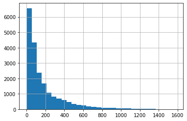

```python
data['days_exposition'].hist(bins=30)
```

Нужно ещё назвать оси. Сделаем это позже. Как мы видим, объявлений, которые висели более года хватает. Думаю, мы можем предположить, что Nan стоит у тех объявлений, которые ещё не сняты с публикации и косяков с этим столбцом не было, как и со столбцом first_day_exposition.

Остались kitchen_area (2278 пропусков) и living_area (1903 пропусков). Давайте посмотрим, насколько они пересекаются.

```python
data.loc[(data['kitchen_area'].isna() == True) & (data['living_area'].isna() == True)]
```

|  | total_images | last_price | total_area | first_day_exposition | rooms | ceiling_height | floors_total | living_area | floor | studio | ... | kitchen_area | balcony | locality_name | airports_nearest | cityCenters_nearest | parks_around3000 | parks_nearest | ponds_around3000 | ponds_nearest | days_exposition |
| --- | --- | --- | --- | --- | --- | --- | --- | --- | --- | --- | --- | --- | --- | --- | --- | --- | --- | --- | --- | --- | --- |
| 3 | 0 | 64900000.0 | 159.0 | 2015-07-24T00:00:00 | 3 | NaN | 14.0 | NaN | 9 | False | ... | NaN | 0.0 | Санкт-Петербург | 28098.0 | 6800.0 | 2.0 | 84.0 | 3.0 | 234.0 | 424.0 |
| 30 | 12 | 2200000.0 | 32.8 | 2018-02-19T00:00:00 | 1 | NaN | 9.0 | NaN | 2 | False | ... | NaN | 0.0 | Коммунар | NaN | -1.0 | NaN | NaN | NaN | NaN | 63.0 |
| 37 | 10 | 1990000.0 | 45.8 | 2017-10-28T00:00:00 | 2 | 2.50 | 5.0 | NaN | 1 | False | ... | NaN | 0.0 | поселок городского типа Красный Бор | NaN | -1.0 | NaN | NaN | NaN | NaN | 196.0 |
| 44 | 13 | 5350000.0 | 40.0 | 2018-11-18T00:00:00 | 1 | NaN | 22.0 | NaN | 3 | False | ... | NaN | 1.0 | Санкт-Петербург | 30471.0 | 11603.0 | 1.0 | 620.0 | 1.0 | 1152.0 | NaN |
| 59 | 15 | 6300000.0 | 46.5 | 2017-03-06T00:00:00 | 1 | NaN | 13.0 | NaN | 13 | False | ... | NaN | 0.0 | Санкт-Петербург | 11125.0 | 14501.0 | 0.0 | -1.0 | 0.0 | -1.0 | 336.0 |
| ... | ... | ... | ... | ... | ... | ... | ... | ... | ... | ... | ... | ... | ... | ... | ... | ... | ... | ... | ... | ... | ... |
| 23632 | 20 | 5000000.0 | 38.0 | 2018-06-23T00:00:00 | 1 | 2.55 | 16.0 | NaN | 15 | False | ... | NaN | 1.0 | Санкт-Петербург | 31118.0 | 7257.0 | 1.0 | 241.0 | 1.0 | 230.0 | 113.0 |
| 23642 | 14 | 5950000.0 | 80.3 | 2018-07-03T00:00:00 | 3 | 2.70 | 12.0 | NaN | 5 | False | ... | NaN | 0.0 | Колпино | 27933.0 | 33719.0 | 0.0 | -1.0 | 2.0 | 562.0 | 60.0 |
| 23663 | 12 | 6400000.0 | 88.0 | 2018-01-12T00:00:00 | 4 | 2.55 | 10.0 | NaN | 1 | False | ... | NaN | 0.0 | Санкт-Петербург | 33642.0 | 13943.0 | 0.0 | -1.0 | 2.0 | 844.0 | 59.0 |
| 23670 | 9 | 2450000.0 | 45.6 | 2018-02-08T00:00:00 | 1 | 2.80 | 9.0 | NaN | 2 | False | ... | NaN | 0.0 | поселок городского типа Синявино | NaN | -1.0 | NaN | NaN | NaN | NaN | 45.0 |
| 23679 | 0 | 2500000.0 | 35.0 | 2017-12-08T00:00:00 | 1 | NaN | 9.0 | NaN | 4 | False | ... | NaN | 0.0 | Сосновый Бор | NaN | -1.0 | NaN | NaN | NaN | NaN | 45.0 |

1464 rows × 21 columns

1464 пропусков. Много пересечений, но хватает и уникальных пропусков. Можно предположить, что эти поля не были обязательными для заполнения пользователями. Опять же, мы могли бы написать код, который бы достаточно неплохо предсказал пропущенные значения и заполнил их, но ведь это не поможет нам в анализе. Нам нужно оценить, как эти факторы влияют на стоимость, а значит усредненные показатели будут только ухудшать качество исследования. Оставим пропуски.

```python
data.isna().sum()
```

```
total_images               0
last_price                 0
total_area                 0
first_day_exposition       0
rooms                      0
ceiling_height          9195
floors_total               0
living_area             1903
floor                      0
studio                     0
open_plan                  0
kitchen_area            2278
balcony                    0
locality_name              0
airports_nearest        5542
cityCenters_nearest        0
parks_around3000        5518
parks_nearest           5518
ponds_around3000        5518
ponds_nearest           5518
days_exposition         3181
dtype: int64
```

Я доволен проделанной работой!

##### Разберёмся с типами данных.

Снова обратимся к инфе о таблице.

```python
data.info()
```

```
<class 'pandas.core.frame.DataFrame'>
RangeIndex: 23699 entries, 0 to 23698
Data columns (total 21 columns):
 #   Column                Non-Null Count  Dtype
---  ------                --------------  -----
 0   total_images          23699 non-null  int64
 1   last_price            23699 non-null  float64
 2   total_area            23699 non-null  float64
 3   first_day_exposition  23699 non-null  object
 4   rooms                 23699 non-null  int64
 5   ceiling_height        14504 non-null  float64
 6   floors_total          23699 non-null  float64
 7   living_area           21796 non-null  float64
 8   floor                 23699 non-null  int64
 9   studio                23699 non-null  bool
 10  open_plan             23699 non-null  bool
 11  kitchen_area          21421 non-null  float64
 12  balcony               23699 non-null  float64
 13  locality_name         23699 non-null  object
 14  airports_nearest      18157 non-null  float64
 15  cityCenters_nearest   23699 non-null  float64
 16  parks_around3000      18181 non-null  float64
 17  parks_nearest         18181 non-null  float64
 18  ponds_around3000      18181 non-null  float64
 19  ponds_nearest         18181 non-null  float64
 20  days_exposition       20518 non-null  float64
dtypes: bool(2), float64(14), int64(3), object(2)
memory usage: 3.5+ MB
```

```python
data['last_price'] = data['last_price'].astype(int)
data['floors_total'] = data['floors_total'].astype(int)
data['balcony'] = data['balcony'].astype(int)
data['first_day_exposition'] = pd.to_datetime(data['first_day_exposition'], format="%Y-%m-%dT%H:%M:%S")
data['first_day_exposition'] = data['first_day_exposition'].dt.floor('D')
```

Проверим.

```python
data.info()
```

```
<class 'pandas.core.frame.DataFrame'>
RangeIndex: 23699 entries, 0 to 23698
Data columns (total 21 columns):
 #   Column                Non-Null Count  Dtype
---  ------                --------------  -----
 0   total_images          23699 non-null  int64
 1   last_price            23699 non-null  int64
 2   total_area            23699 non-null  float64
 3   first_day_exposition  23699 non-null  datetime64[ns]
 4   rooms                 23699 non-null  int64
 5   ceiling_height        14504 non-null  float64
 6   floors_total          23699 non-null  int64
 7   living_area           21796 non-null  float64
 8   floor                 23699 non-null  int64
 9   studio                23699 non-null  bool
 10  open_plan             23699 non-null  bool
 11  kitchen_area          21421 non-null  float64
 12  balcony               23699 non-null  int64
 13  locality_name         23699 non-null  object
 14  airports_nearest      18157 non-null  float64
 15  cityCenters_nearest   23699 non-null  float64
 16  parks_around3000      18181 non-null  float64
 17  parks_nearest         18181 non-null  float64
 18  ponds_around3000      18181 non-null  float64
 19  ponds_nearest         18181 non-null  float64
 20  days_exposition       20518 non-null  float64
dtypes: bool(2), datetime64[ns](1), float64(11), int64(6), object(1)
memory usage: 3.5+ MB
```

```python
data['first_day_exposition'].head()
```

```
0   2019-03-07
1   2018-12-04
2   2015-08-20
3   2015-07-24
4   2018-06-19
Name: first_day_exposition, dtype: datetime64[ns]
```

##### Разберёмся с неявными дубликатами в столбце locality_name

Давайте изучим уникальные значения.

```python
data['locality_name'].sort_values().unique()
```

```
array(['Бокситогорск', 'Волосово', 'Волхов', 'Всеволожск', 'Выборг',
       'Высоцк', 'Гатчина', 'Зеленогорск', 'Ивангород', 'Каменногорск',
       'Кингисепп', 'Кириши', 'Кировск', 'Колпино', 'Коммунар',
       'Красное Село', 'Кронштадт', 'Кудрово', 'Лодейное Поле',
       'Ломоносов', 'Луга', 'Любань', 'Мурино', 'Никольское',
       'Новая Ладога', 'Отрадное', 'Павловск', 'Петергоф', 'Пикалёво',
       'Подпорожье', 'Приморск', 'Приозерск', 'Пушкин', 'Санкт-Петербург',
       'Светогорск', 'Сертолово', 'Сестрорецк', 'Сланцы', 'Сосновый Бор',
       'Сясьстрой', 'Тихвин', 'Тосно', 'Шлиссельбург',
       'городской поселок Большая Ижора', 'городской поселок Янино-1',
       'городской посёлок Будогощь', 'городской посёлок Виллози',
       'городской посёлок Лесогорский', 'городской посёлок Мга',
       'городской посёлок Назия', 'городской посёлок Новоселье',
       'городской посёлок Павлово', 'городской посёлок Рощино',
       'городской посёлок Свирьстрой', 'городской посёлок Советский',
       'городской посёлок Фёдоровское', 'городской посёлок Янино-1',
       'деревня Агалатово', 'деревня Аро', 'деревня Батово',
       'деревня Бегуницы', 'деревня Белогорка', 'деревня Большая Вруда',
       'деревня Большая Пустомержа', 'деревня Большие Колпаны',
       'деревня Большое Рейзино', 'деревня Большой Сабск', 'деревня Бор',
       'деревня Борисова Грива', 'деревня Ваганово', 'деревня Вартемяги',
       'деревня Вахнова Кара', 'деревня Выскатка', 'деревня Гарболово',
       'деревня Глинка', 'деревня Горбунки', 'деревня Гостилицы',
       'деревня Заклинье', 'деревня Заневка', 'деревня Зимитицы',
       'деревня Извара', 'деревня Иссад', 'деревня Калитино',
       'деревня Кальтино', 'деревня Камышовка', 'деревня Каськово',
       'деревня Келози', 'деревня Кипень', 'деревня Кисельня',
       'деревня Колтуши', 'деревня Коркино', 'деревня Котлы',
       'деревня Кривко', 'деревня Кудрово', 'деревня Кузьмолово',
       'деревня Курковицы', 'деревня Куровицы', 'деревня Куттузи',
       'деревня Лаврики', 'деревня Лаголово', 'деревня Лампово',
       'деревня Лесколово', 'деревня Лопухинка', 'деревня Лупполово',
       'деревня Малая Романовка', 'деревня Малое Верево',
       'деревня Малое Карлино', 'деревня Малые Колпаны',
       'деревня Мануйлово', 'деревня Меньково', 'деревня Мины',
       'деревня Мистолово', 'деревня Ненимяки', 'деревня Нижние Осельки',
       'деревня Нижняя', 'деревня Низино', 'деревня Новое Девяткино',
       'деревня Новолисино', 'деревня Нурма', 'деревня Оржицы',
       'деревня Парицы', 'деревня Пельгора', 'деревня Пеники',
       'деревня Пижма', 'деревня Пикколово', 'деревня Пудомяги',
```

[output cut: 96 more lines]

```
       'посёлок городского типа Тайцы', 'посёлок городского типа Токсово',
       'посёлок городского типа Ульяновка',
       'посёлок городского типа Форносово',
       'посёлок городского типа имени Морозова',
       'посёлок городского типа имени Свердлова',
       'посёлок при железнодорожной станции Вещево',
       'посёлок при железнодорожной станции Приветнинское',
       'посёлок станции Громово', 'посёлок станции Свирь',
       'садоводческое некоммерческое товарищество Лесная Поляна',
       'садовое товарищество Новая Ропша',
       'садовое товарищество Приладожский', 'садовое товарищество Рахья',
       'садовое товарищество Садко', 'село Копорье', 'село Никольское',
       'село Павлово', 'село Паша', 'село Путилово', 'село Рождествено',
       'село Русско-Высоцкое', 'село Старая Ладога', 'село Шум'],
      dtype=object)
```

```python
data['locality_name'].nunique()
```

```
364
```

Я думаю, сначала нужно заменить все вариации посёлков на "поселок".

```python
def normalize_name(name):
    name = name.replace('посёлок', 'поселок')
    name = name.replace('поселок городского типа', 'поселок')
    name = name.replace('городской поселок', 'поселок')
    return name

data['locality_name'] = data['locality_name'].apply(normalize_name)
```

```python
data['locality_name'].sort_values().unique()
```

```
array(['Бокситогорск', 'Волосово', 'Волхов', 'Всеволожск', 'Выборг',
       'Высоцк', 'Гатчина', 'Зеленогорск', 'Ивангород', 'Каменногорск',
       'Кингисепп', 'Кириши', 'Кировск', 'Колпино', 'Коммунар',
       'Красное Село', 'Кронштадт', 'Кудрово', 'Лодейное Поле',
       'Ломоносов', 'Луга', 'Любань', 'Мурино', 'Никольское',
       'Новая Ладога', 'Отрадное', 'Павловск', 'Петергоф', 'Пикалёво',
       'Подпорожье', 'Приморск', 'Приозерск', 'Пушкин', 'Санкт-Петербург',
       'Светогорск', 'Сертолово', 'Сестрорецк', 'Сланцы', 'Сосновый Бор',
       'Сясьстрой', 'Тихвин', 'Тосно', 'Шлиссельбург',
       'деревня Агалатово', 'деревня Аро', 'деревня Батово',
       'деревня Бегуницы', 'деревня Белогорка', 'деревня Большая Вруда',
       'деревня Большая Пустомержа', 'деревня Большие Колпаны',
       'деревня Большое Рейзино', 'деревня Большой Сабск', 'деревня Бор',
       'деревня Борисова Грива', 'деревня Ваганово', 'деревня Вартемяги',
       'деревня Вахнова Кара', 'деревня Выскатка', 'деревня Гарболово',
       'деревня Глинка', 'деревня Горбунки', 'деревня Гостилицы',
       'деревня Заклинье', 'деревня Заневка', 'деревня Зимитицы',
       'деревня Извара', 'деревня Иссад', 'деревня Калитино',
       'деревня Кальтино', 'деревня Камышовка', 'деревня Каськово',
       'деревня Келози', 'деревня Кипень', 'деревня Кисельня',
       'деревня Колтуши', 'деревня Коркино', 'деревня Котлы',
       'деревня Кривко', 'деревня Кудрово', 'деревня Кузьмолово',
       'деревня Курковицы', 'деревня Куровицы', 'деревня Куттузи',
       'деревня Лаврики', 'деревня Лаголово', 'деревня Лампово',
       'деревня Лесколово', 'деревня Лопухинка', 'деревня Лупполово',
       'деревня Малая Романовка', 'деревня Малое Верево',
       'деревня Малое Карлино', 'деревня Малые Колпаны',
       'деревня Мануйлово', 'деревня Меньково', 'деревня Мины',
       'деревня Мистолово', 'деревня Ненимяки', 'деревня Нижние Осельки',
       'деревня Нижняя', 'деревня Низино', 'деревня Новое Девяткино',
       'деревня Новолисино', 'деревня Нурма', 'деревня Оржицы',
       'деревня Парицы', 'деревня Пельгора', 'деревня Пеники',
       'деревня Пижма', 'деревня Пикколово', 'деревня Пудомяги',
       'деревня Пустынка', 'деревня Пчева', 'деревня Рабитицы',
       'деревня Разбегаево', 'деревня Раздолье', 'деревня Разметелево',
       'деревня Рапполово', 'деревня Реброво', 'деревня Русско',
       'деревня Сижно', 'деревня Снегирёвка', 'деревня Старая',
       'деревня Старая Пустошь', 'деревня Старое Хинколово',
       'деревня Старополье', 'деревня Старосиверская',
       'деревня Старые Бегуницы', 'деревня Суоранда',
```

[output cut: 58 more lines]

```
       'поселок Шугозеро', 'поселок Шушары', 'поселок Щеглово',
       'поселок Янино-1', 'поселок имени Морозова',
       'поселок имени Свердлова',
       'поселок при железнодорожной станции Вещево',
       'поселок при железнодорожной станции Приветнинское',
       'поселок станции Вещево', 'поселок станции Громово',
       'поселок станции Корнево', 'поселок станции Лужайка',
       'поселок станции Приветнинское', 'поселок станции Свирь',
       'садоводческое некоммерческое товарищество Лесная Поляна',
       'садовое товарищество Новая Ропша',
       'садовое товарищество Приладожский', 'садовое товарищество Рахья',
       'садовое товарищество Садко', 'село Копорье', 'село Никольское',
       'село Павлово', 'село Паша', 'село Путилово', 'село Рождествено',
       'село Русско-Высоцкое', 'село Старая Ладога', 'село Шум'],
      dtype=object)
```

```python
data['locality_name'].nunique()
```

```
322
```

Супер. Давайте ещё попробуем удалить дубликаты вида "Мурино" и "поселок Мурино".

```python
def drop_names(series):
    names = series.tolist()
    normalized = []

    for name in names:
        # Разбиваем название на слова
        parts = name.split()

        # Ищем самое короткое название, которое является частью текущего
        shortest_match = None
        for other in names:
            if other == name:
                continue
            # Если текущее название содержит другое (например, "поселок Мурино" содержит "Мурино")
            if other in name:
                if shortest_match is None or len(other) < len(shortest_match):
                    shortest_match = other
            # Или если другое название содержит текущее (например, "Мурино" содержится в "поселок Мурино")
            elif name in other:
                if shortest_match is None or len(name) < len(shortest_match):
                    shortest_match = name

        # Если нашли более короткий вариант, берём его, иначе оставляем исходный
        normalized.append(shortest_match if shortest_match else name)

    return pd.Series(normalized, index=series.index)

# Применяем функцию
data['locality_name'] = drop_names(data['locality_name'])
```

Для написания этой функции я пользовался дипсиком. Думаю, это было удачное место для его помощи. Посмотрим на итог.

```python
data['locality_name'].nunique()
```

```
311
```

ВЕ-ЛИ-КО-ЛЕП-НО!

С предобработкой закончили, едем дальше.

### Посчитайте и добавьте в таблицу новые столбцы

Нам нужно добавить следующие столбцы:

- цена одного квадратного метра (нужно поделить стоимость объекта на его общую площадь, а затем округлить до двух знаков после запятой);
- день недели публикации объявления (0 — понедельник, 1 — вторник и так далее);
- месяц публикации объявления;
- год публикации объявления;
- тип этажа квартиры (значения — «первый», «последний», «другой»);
- расстояние до центра города в километрах (переведите из м в км и округлите до ближайших целых значений).

Начнём с цены за кадратный метр.

```python
data['square_cost'] = data['last_price'] / data['total_area']
data['square_cost'] = data['square_cost'].round(2)
data['square_cost'].head()
```

```
0    120370.37
1     82920.79
2     92785.71
3    408176.10
4    100000.00
Name: square_cost, dtype: float64
```

Как два пальца... В общем, раз плюнуть.

```python
data['weekday'] = data['first_day_exposition'].dt.weekday
data['weekday'].head()
```

```
0    3
1    1
2    3
3    4
4    1
Name: weekday, dtype: int64
```

Добавили столбец. Но сейчас с нём порядковые числа дней недели (0,1,2...). Исправим на русскоязычные названия.

```python
weekday_map = {
        0: 'понедельник',
        1: 'вторник',
        2: 'среда',
        3: 'четверг',
        4: 'пятница',
        5: 'суббота',
        6: 'воскресенье'
    }

data['weekday'] = data['weekday'].map(weekday_map)



data['weekday'].head()
```

```
0    четверг
1    вторник
2    четверг
3    пятница
4    вторник
Name: weekday, dtype: object
```

```python
data['month'] = data['first_day_exposition'].dt.month
```

```python
data['month'].head()
```

```
0     3
1    12
2     8
3     7
4     6
Name: month, dtype: int64
```

Меняем числа на названия.

```python
month_map = {
        1: 'январь',
        2: 'февраль',
        3: 'март',
        4: 'апрель',
        5: 'май',
        6: 'июнь',
        7: 'июль',
        8: 'август',
        9: 'сентябрь',
        10: 'октябрь',
        11: 'ноябрь',
        12: 'декабрь'
    }

data['month'] = data['month'].map(month_map)

data['month'].head()
```

```
0       март
1    декабрь
2     август
3       июль
4       июнь
Name: month, dtype: object
```

Супер. Теперь год.

```python
data['year'] = data['first_day_exposition'].dt.year
```

```python
data['year'].head()
```

```
0    2019
1    2018
2    2015
3    2015
4    2018
Name: year, dtype: int64
```

А теперь сделаем столбец с типом этажа - «первый», «последний», «другой».

```python
data['floor_type'] = 'другой'
```

```python
data['floor_type'].head()
```

```
0    другой
1    другой
2    другой
3    другой
4    другой
Name: floor_type, dtype: object
```

Не забываем про строки, где floors_total было пропущено и мы поставили -1. Присвоим floor_type значение 'неизвестно'.

```python
data.loc[data['floors_total'] == -1, 'floor_type'] = 'неизвестно'
```

Мы сделали столбец, в котором у всех строк значение типа этажа - другой. Теперь исправим это значение для строк, где этаж является первым или последним.

```python
data.loc[data['floor'] == 1, 'floor_type'] = 'первый'
data.loc[data['floor'] == data['floors_total'], 'floor_type'] = 'последний'
```

```python
data[['floor', 'floors_total', 'floor_type']].head(15)
```

|  | floor | floors_total | floor_type |
| --- | --- | --- | --- |
| 0 | 8 | 16 | другой |
| 1 | 1 | 11 | первый |
| 2 | 4 | 5 | другой |
| 3 | 9 | 14 | другой |
| 4 | 13 | 14 | другой |
| 5 | 5 | 12 | другой |
| 6 | 6 | 26 | другой |
| 7 | 22 | 24 | другой |
| 8 | 26 | 27 | другой |
| 9 | 7 | 9 | другой |
| 10 | 3 | 12 | другой |
| 11 | 4 | 5 | другой |
| 12 | 5 | 5 | последний |
| 13 | 5 | 5 | последний |
| 14 | 1 | 6 | первый |

```python
data['floor_type'].value_counts()
```

```
другой        17363
последний      3361
первый         2892
неизвестно       83
Name: floor_type, dtype: int64
```

Классно. Теперь округлённое расстояние до центра города в километрах.

Давайте, кстати, поменяем название столбца cityCenters_nearest на более адекватное. Лучше поздно, чем никогда.

```python
data = data.rename(columns={'cityCenters_nearest': 'centers_range'})
```

```python
data['centers_range_km'] = (data['centers_range']/1000).round(0)
```

```python
data[['centers_range', 'centers_range_km']].head()
```

|  | centers_range | centers_range_km |
| --- | --- | --- |
| 0 | 16028.0 | 16.0 |
| 1 | 18603.0 | 19.0 |
| 2 | 13933.0 | 14.0 |
| 3 | 6800.0 | 7.0 |
| 4 | 8098.0 | 8.0 |

Ай да я!

### Проведите исследовательский анализ данных

#### Изучим перечисленные ниже параметры объектов и построим отдельные гистограммы для каждого из этих них. В некоторых параметрах встречаются редкие и выбивающиеся значения, обработаем их.

- общая площадь;
- жилая площадь;
- площадь кухни;
- цена объекта;
- количество комнат;
- высота потолков;
- тип этажа квартиры («первый», «последний», «другой»);
- общее количество этажей в доме;
- расстояние до центра города в метрах;
- расстояние до ближайшего парка

**Общая площадь**

Начнём с общей площади. Сначала посмотрим описание выборки, созданное методом describe, а затем построим гистограмму с названиями осей.

```python
data['total_area'].describe()
```

```
count    23699.000000
mean        60.348651
std         35.654083
min         12.000000
25%         40.000000
50%         52.000000
75%         69.900000
max        900.000000
Name: total_area, dtype: float64
```

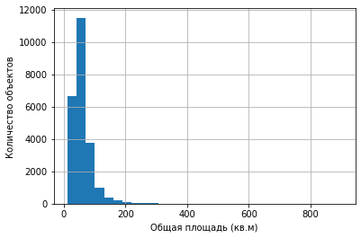

```python
data['total_area'].hist(bins=30)
plt.xlabel('Общая площадь (кв.м)')
plt.ylabel('Количество объектов')
plt.show()
```

Здесь я названия расписал. Дальше не буду, т.к. и так всё понятно и, эта работа в первую очередь для меня. Не хочу тратить время.

```python
data.loc[data['total_area'] > 400, ['total_area', 'last_price', 'square_cost']]
```

|  | total_area | last_price | square_cost |
| --- | --- | --- | --- |
| 660 | 483.90 | 49950000 | 103223.81 |
| 3117 | 631.00 | 140000000 | 221870.05 |
| 3676 | 441.98 | 28789000 | 65136.43 |
| 4237 | 517.00 | 50000000 | 96711.80 |
| 5358 | 590.00 | 65000000 | 110169.49 |
| 5893 | 500.00 | 230000000 | 460000.00 |
| 6221 | 470.30 | 34000000 | 72294.28 |
| 6621 | 488.00 | 99000000 | 202868.85 |
| 8018 | 507.00 | 84000000 | 165680.47 |
| 9826 | 494.10 | 43185328 | 87402.00 |
| 12401 | 495.00 | 91500000 | 184848.48 |
| 12859 | 631.20 | 140000000 | 221799.75 |
| 13749 | 410.00 | 240000000 | 585365.85 |
| 14088 | 402.00 | 51000000 | 126865.67 |
| 14706 | 401.00 | 401300000 | 1000748.13 |
| 14991 | 413.50 | 45000000 | 108827.09 |
| 15016 | 500.00 | 150000000 | 300000.00 |
| 15651 | 618.00 | 300000000 | 485436.89 |
| 19540 | 900.00 | 420000000 | 466666.67 |
| 20273 | 460.80 | 20000000 | 43402.78 |
| 21955 | 431.00 | 130000000 | 301624.13 |
| 22131 | 422.20 | 27000000 | 63950.73 |
| 22494 | 491.00 | 91075000 | 185488.80 |

Проверим варианты с самой низкой ценой за кв.м.

```python
data.loc[20273]
```

```
total_images                             12
last_price                         20000000
total_area                            460.8
first_day_exposition    2019-03-20 00:00:00
rooms                                     6
ceiling_height                          3.1
floors_total                              3
living_area                           279.6
floor                                     1
studio                                False
open_plan                             False
kitchen_area                           55.5
balcony                                   0
locality_name               Санкт-Петербург
airports_nearest                    43756.0
centers_range                       15459.0
parks_around3000                        1.0
parks_nearest                         852.0
ponds_around3000                        3.0
ponds_nearest                         122.0
days_exposition                        21.0
square_cost                        43402.78
weekday                               среда
month                                  март
year                                   2019
floor_type                           первый
centers_range_km                       15.0
Name: 20273, dtype: object
```

Наверное частный дом. 3 этажа, большая площадь кухни, жилая площадь меньше 2/3. Всё в порядке.

```python
data.loc[22131]
```

```
total_images                             14
last_price                         27000000
total_area                            422.2
first_day_exposition    2018-10-18 00:00:00
rooms                                     5
ceiling_height                          2.7
floors_total                             13
living_area                             NaN
floor                                    11
studio                                False
open_plan                             False
kitchen_area                            NaN
balcony                                   0
locality_name               Санкт-Петербург
airports_nearest                    46625.0
centers_range                       16554.0
parks_around3000                        0.0
parks_nearest                          -1.0
ponds_around3000                        0.0
ponds_nearest                          -1.0
days_exposition                         NaN
square_cost                        63950.73
weekday                             четверг
month                               октябрь
year                                   2018
floor_type                           другой
centers_range_km                       17.0
Name: 22131, dtype: object
```

Значит исправлять нечего. Только удалять. Давайте определимся, где делать отрез. Посмотрим на ящик с усами.

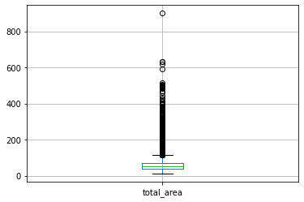

```python
data.boxplot(column='total_area')
```

Начиная с 400 кв.м. значений явно мало. Давайте посмотрим, где верхний ус.

```
(100.0, 150.0)
```

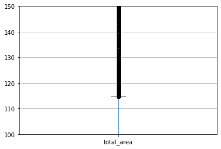

```python
data.boxplot(column='total_area')
plt.ylim(100, 150)
```

Около 115. Но после этого значения ещё много выбросов. Посмотрим на гистограмму с распределением поближе.

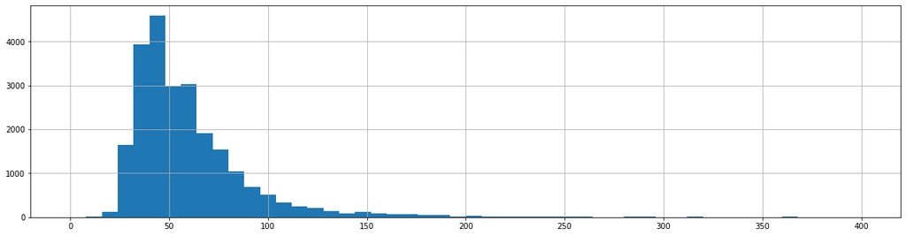

```python
data['total_area'].hist(bins=50, range=(0,400), figsize=(20,5))
```

После 150 значений мало, после 200 вообще почти нет. Давайте сделаем отсечку по 200. Посмотрим describe с этой границей.

```python
data[data['total_area'] < 200]['total_area'].describe()
```

```
count    23468.000000
mean        58.155629
std         26.469479
min         12.000000
25%         40.000000
50%         51.900000
75%         68.900000
max        199.200000
Name: total_area, dtype: float64
```

Так получше. Среднее с медианой немного сблизились. Станд.отклон упал с ~35,5 до ~26,5.

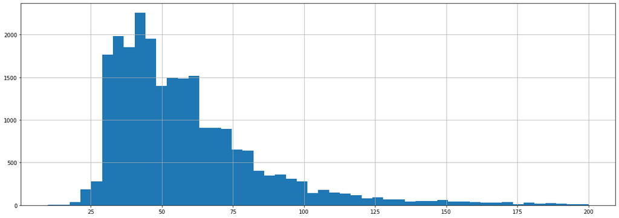

```python
data['total_area'].hist(bins=50, range=(10,200), figsize=(20,7))
```

Красота.

**Жилая площадь**

Снова начнём с описания и гистограммы.

```python
data['living_area'].describe()
```

```
count    21796.000000
mean        34.457852
std         22.030445
min          2.000000
25%         18.600000
50%         30.000000
75%         42.300000
max        409.700000
Name: living_area, dtype: float64
```

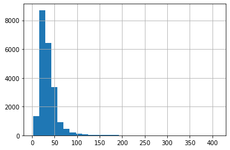

```python
data['living_area'].hist(bins=30)
```

Значения меньше, а общая картина идентичная. Закономерно. Меня только смущает минимум. 2 кв.м? Это прихожая в студии? Я хочу изучить.

```python
data[data['living_area'] < 10]['living_area'].count()
```

```
25
```

```python
data[data['living_area'] < 10]
```

|  | total_images | last_price | total_area | first_day_exposition | rooms | ceiling_height | floors_total | living_area | floor | studio | ... | parks_nearest | ponds_around3000 | ponds_nearest | days_exposition | square_cost | weekday | month | year | floor_type | centers_range_km |
| --- | --- | --- | --- | --- | --- | --- | --- | --- | --- | --- | --- | --- | --- | --- | --- | --- | --- | --- | --- | --- | --- |
| 114 | 5 | 4000000 | 21.40 | 2019-02-07 | 1 | 2.90 | 8 | 8.3 | 7 | False | ... | 488.0 | 1.0 | 286.0 | NaN | 186915.89 | четверг | февраль | 2019 | другой | 6.0 |
| 680 | 14 | 7200000 | 43.00 | 2017-10-31 | 1 | NaN | 8 | 9.0 | 2 | False | ... | 2137.0 | 1.0 | 933.0 | 296.0 | 167441.86 | вторник | октябрь | 2017 | другой | 5.0 |
| 1326 | 8 | 8100000 | 52.00 | 2017-01-29 | 2 | 2.70 | 25 | 9.0 | 15 | False | ... | -1.0 | 1.0 | 1180.0 | 337.0 | 155769.23 | воскресенье | январь | 2017 | другой | 16.0 |
| 2309 | 10 | 4200000 | 62.40 | 2017-06-15 | 2 | 2.60 | 9 | 8.4 | 6 | False | ... | -1.0 | 0.0 | -1.0 | 111.0 | 67307.69 | четверг | июнь | 2017 | другой | 29.0 |
| 3242 | 7 | 4440000 | 41.00 | 2017-07-02 | 1 | NaN | 17 | 3.0 | 17 | False | ... | -1.0 | 0.0 | -1.0 | 216.0 | 108292.68 | воскресенье | июль | 2017 | последний | 13.0 |
| 4100 | 17 | 5300000 | 34.80 | 2017-06-19 | 1 | 2.70 | 23 | 9.0 | 15 | False | ... | -1.0 | 0.0 | -1.0 | 30.0 | 152298.85 | понедельник | июнь | 2017 | другой | 13.0 |
| 4542 | 12 | 3300000 | 18.00 | 2018-11-07 | 1 | 3.50 | 5 | 9.0 | 2 | False | ... | 349.0 | 1.0 | 963.0 | 9.0 | 183333.33 | среда | ноябрь | 2018 | другой | 5.0 |
| 7312 | 8 | 3400000 | 27.00 | 2018-02-21 | 2 | 2.50 | 15 | 9.0 | 4 | False | ... | 617.0 | 0.0 | -1.0 | NaN | 125925.93 | среда | февраль | 2018 | другой | 16.0 |
| 8325 | 9 | 4800000 | 52.00 | 2017-10-25 | 2 | NaN | 5 | 9.0 | 2 | False | ... | -1.0 | 2.0 | 118.0 | 119.0 | 92307.69 | среда | октябрь | 2017 | другой | 13.0 |
| 13915 | 20 | 6350000 | 52.00 | 2018-02-06 | 2 | 3.00 | 6 | 2.0 | 2 | False | ... | -1.0 | 1.0 | 1012.0 | 91.0 | 122115.38 | вторник | февраль | 2018 | другой | 7.0 |
| 15833 | 20 | 4600000 | 33.00 | 2017-01-01 | 1 | 2.70 | 22 | 9.0 | 12 | False | ... | -1.0 | 0.0 | -1.0 | 511.0 | 139393.94 | воскресенье | январь | 2017 | другой | 14.0 |
| 16431 | 13 | 3799000 | 31.00 | 2018-04-12 | 1 | 2.60 | 5 | 6.0 | 1 | False | ... | 430.0 | 0.0 | -1.0 | 168.0 | 122548.39 | четверг | апрель | 2018 | первый | 5.0 |
| 17248 | 20 | 5300000 | 33.00 | 2017-04-14 | 1 | 2.70 | 22 | 8.9 | 16 | False | ... | -1.0 | 0.0 | -1.0 | 216.0 | 160606.06 | пятница | апрель | 2017 | другой | 14.0 |
| 17582 | 11 | 2680000 | 22.00 | 2018-08-11 | 0 | NaN | 25 | 5.0 | 8 | True | ... | 835.0 | 1.0 | 652.0 | 70.0 | 121818.18 | суббота | август | 2018 | другой | 12.0 |
| 19251 | 19 | 4050000 | 33.00 | 2018-10-15 | 1 | 2.50 | 22 | 6.5 | 21 | False | ... | 458.0 | 0.0 | -1.0 | 44.0 | 122727.27 | понедельник | октябрь | 2018 | другой | 11.0 |
| 19620 | 10 | 4300000 | 33.00 | 2018-02-01 | 1 | NaN | 5 | 9.0 | 1 | False | ... | 251.0 | 3.0 | 220.0 | 86.0 | 130303.03 | четверг | февраль | 2018 | первый | 3.0 |
| 20994 | 7 | 8900000 | 50.60 | 2018-10-22 | 2 | 2.50 | 7 | 8.0 | 3 | False | ... | 173.0 | 3.0 | 126.0 | NaN | 175889.33 | понедельник | октябрь | 2018 | другой | 8.0 |
| 21505 | 9 | 4100000 | 35.30 | 2018-01-10 | 1 | 2.75 | 27 | 8.5 | 11 | False | ... | -1.0 | 0.0 | -1.0 | 60.0 | 116147.31 | среда | январь | 2018 | другой | 15.0 |
| 21758 | 0 | 2330000 | 23.00 | 2018-01-01 | 0 | NaN | 24 | 2.0 | 22 | True | ... | NaN | NaN | NaN | 66.0 | 101304.35 | понедельник | январь | 2018 | другой | -0.0 |
| 21908 | 9 | 5300000 | 46.30 | 2018-03-20 | 1 | 2.75 | 7 | 9.8 | 3 | False | ... | -1.0 | 1.0 | 1144.0 | 36.0 | 114470.84 | вторник | март | 2018 | другой | 32.0 |
| 21943 | 15 | 6100000 | 77.60 | 2019-02-28 | 4 | 2.50 | 9 | 5.4 | 1 | False | ... | 584.0 | 0.0 | -1.0 | 33.0 | 78608.25 | четверг | февраль | 2019 | первый | 11.0 |
| 22252 | 4 | 3340000 | 37.40 | 2018-02-08 | 1 | 2.80 | 8 | 9.0 | 4 | False | ... | 365.0 | 0.0 | -1.0 | 233.0 | 89304.81 | четверг | февраль | 2018 | другой | 19.0 |
| 22473 | 0 | 3490304 | 33.26 | 2015-12-22 | 2 | NaN | 13 | 9.1 | 9 | False | ... | -1.0 | 0.0 | -1.0 | 199.0 | 104939.99 | вторник | декабрь | 2015 | другой | 13.0 |
| 23208 | 12 | 4800000 | 37.00 | 2016-02-24 | 1 | NaN | 14 | 8.0 | 11 | False | ... | 358.0 | 1.0 | 950.0 | 139.0 | 129729.73 | среда | февраль | 2016 | другой | 12.0 |
| 23574 | 14 | 64990000 | 139.00 | 2015-11-24 | 3 | 3.00 | 8 | 3.0 | 8 | False | ... | 630.0 | 3.0 | 100.0 | 280.0 | 467553.96 | вторник | ноябрь | 2015 | последний | 6.0 |

25 rows × 27 columns

Какая-то шняга. Давайте не будем это учитывать.

Что там с усатиком?

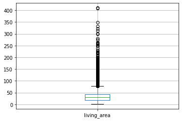

```python
data.boxplot(column='living_area')
```

После 200 выбросов сильно меньше. Построим гистограмму с этим ограничением, но сначала найдём верхний ус.

```
(65.0, 80.0)
```

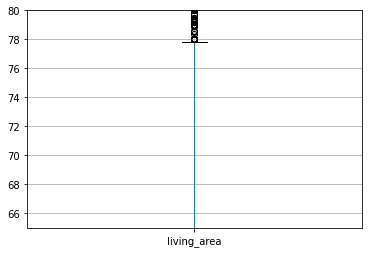

```python
data.boxplot(column='living_area')
plt.ylim(65, 80)
```

Почти 78. Гистограмма?

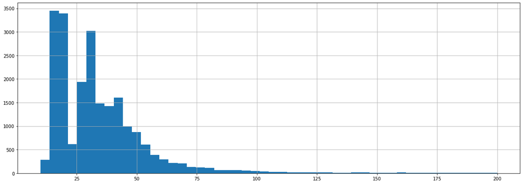

```python
data['living_area'].hist(bins=50, range=(10,200), figsize=(20,7))
```

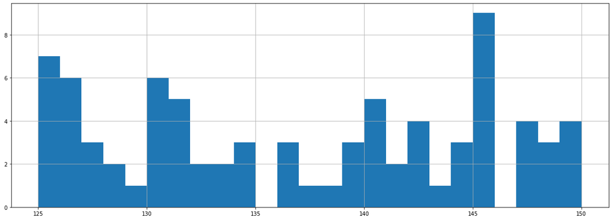

```python
data['living_area'].hist(bins=25, range=(125,150), figsize=(20,7))
```

Я бы забил на это и остановился на 125.

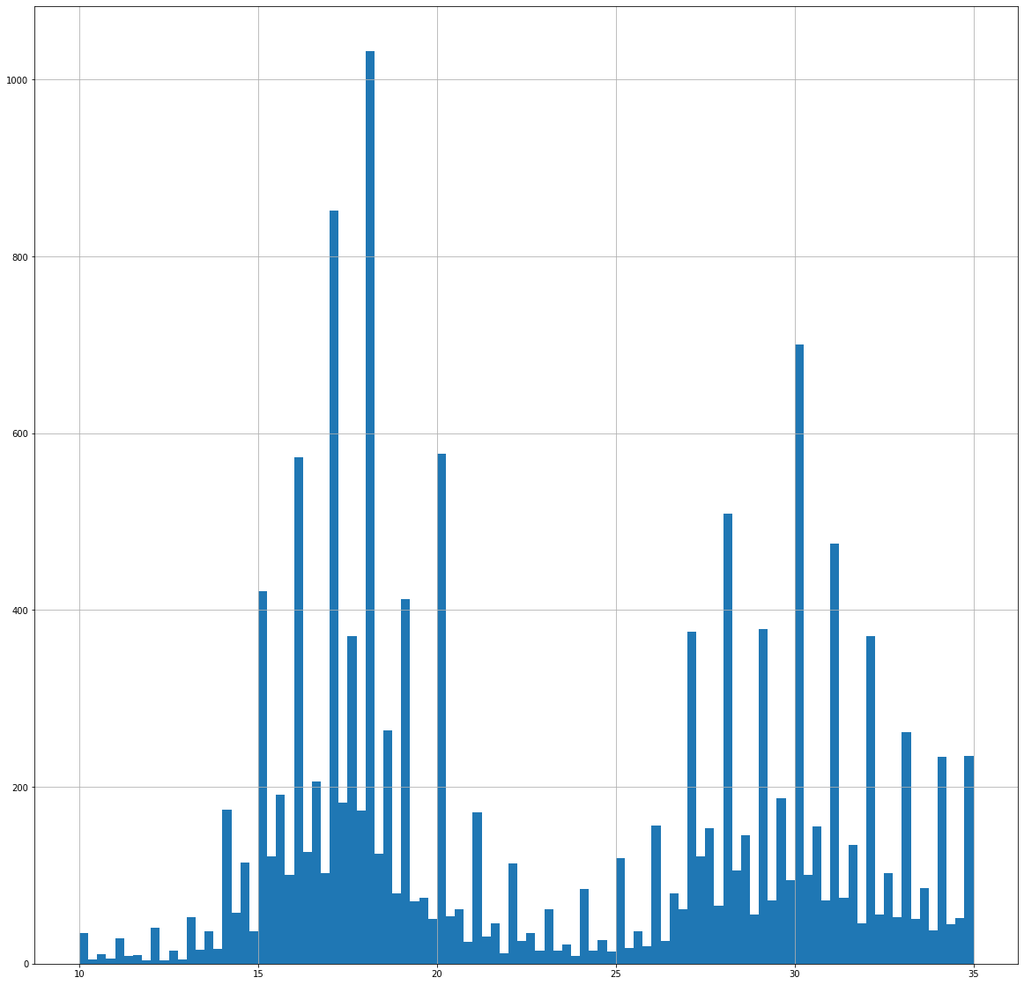

```python
data['living_area'].hist(bins=100, range=(10,35), figsize=(20,20))
```

Я не уверен, как называется такое распределение. Нет, в целом распределение на общем графике выглядит как логнормальное с аномалиями, и к этим выбросами стоит отнестись спокойно. Наверняка это типичные показатели для однушек и двушек. На общем графике видно и третий подъем, просто менее выраженный. Уверен, это типичная площадь для трешки. Комнат больше, следовательно больше гладкости в распределении, а пики короче. Не вижу смысла проверять детально. Чекнем медианы жилой площади по количеству комнат.

```python
data.groupby('rooms')['living_area'].median()
```

```
rooms
0      18.000
1      17.600
2      30.500
3      45.000
4      63.600
5      91.785
6     123.900
7     145.000
8     161.000
9     179.200
10    161.400
11    133.900
12    409.700
14    195.150
15    409.000
16    180.000
19    264.500
Name: living_area, dtype: float64
```

Сделаем срез до 125 и опишем результат.

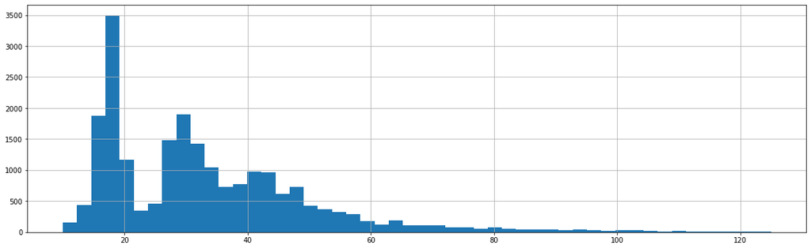

```python
data['living_area'].hist(bins=50, range=(10,125), figsize=(20,6))
```

Не, немного кринжово выглядит, я согласен. Но моё объяснение всё объясняет.

Было:

```python
data['living_area'].describe()
```

```
count    21796.000000
mean        34.457852
std         22.030445
min          2.000000
25%         18.600000
50%         30.000000
75%         42.300000
max        409.700000
Name: living_area, dtype: float64
```

Стало:

```python
data[(data['living_area'] >= 10) & (data['living_area'] < 125)]['living_area'].describe()
```

```
count    21572.000000
mean        33.220543
std         17.057882
min         10.000000
25%         18.600000
50%         30.000000
75%         42.000000
max        124.900000
Name: living_area, dtype: float64
```

Покрасивше. До чего же устойчивые квартили. Это потому что данные тяготеют к типичным площадям 1, 2 и 3-х комнатных квартир. Больше всего снизился вновь станд.отклон.

**Площадь кухни**

```python
data['kitchen_area'].describe()
```

```
count    21421.000000
mean        10.569807
std          5.905438
min          1.300000
25%          7.000000
50%          9.100000
75%         12.000000
max        112.000000
Name: kitchen_area, dtype: float64
```

Выглядит лучше, но это из-за того, что числа маленькие. Разница между средним и медианой больше, чем 1/10 от значений. Станд.отклон. больше, чем половина среднего. Так себе, в общем. Большой разброс.

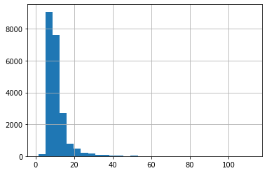

```python
data['kitchen_area'].hist(bins=30)
```

Кухня 1.3 метра - это конечно лучше, чем жилая зона 2 метра, но всё же плохо. Давайте посмотрим на квартиры с кухнями меньше 4 метров.

```python
data[data['kitchen_area'] < 4][['last_price', 'locality_name', 'centers_range', 'total_area', 'living_area', 'kitchen_area']]
```

|  | last_price | locality_name | centers_range | total_area | living_area | kitchen_area |
| --- | --- | --- | --- | --- | --- | --- |
| 906 | 2600000 | Санкт-Петербург | 17459.0 | 27.00 | 18.0 | 2.00 |
| 2165 | 3180000 | Мурино | -1.0 | 25.00 | 17.0 | 3.00 |
| 3078 | 6000000 | Санкт-Петербург | 5247.0 | 43.00 | 29.3 | 3.20 |
| 3195 | 2690000 | Санкт-Петербург | 11281.0 | 25.60 | 16.2 | 3.80 |
| 6084 | 770000 | Тихвин | -1.0 | 18.00 | 13.0 | 3.00 |
| 6262 | 3100000 | Санкт-Петербург | 4914.0 | 24.00 | 16.0 | 2.00 |
| 7047 | 2800000 | Санкт-Петербург | 3974.0 | 21.00 | 14.9 | 3.80 |
| 7950 | 5967734 | Санкт-Петербург | 20802.0 | 66.40 | 44.4 | 2.89 |
| 8712 | 14948000 | Санкт-Петербург | 3914.0 | 42.70 | 27.5 | 3.70 |
| 8729 | 2200000 | Пушкин | 30687.0 | 18.40 | 14.0 | 2.40 |
| 9138 | 2920000 | Санкт-Петербург | 4008.0 | 23.29 | 21.0 | 2.00 |
| 10058 | 3350000 | поселок Шушары | -1.0 | 25.00 | 17.0 | 3.50 |
| 10208 | 1900000 | Санкт-Петербург | 5639.0 | 17.00 | 13.0 | 3.00 |
| 11033 | 5350000 | Санкт-Петербург | 3953.0 | 32.00 | 16.0 | 2.00 |
| 11475 | 2500000 | деревня Яльгелево | -1.0 | 40.80 | 26.8 | 3.80 |
| 12370 | 7575000 | Санкт-Петербург | 14545.0 | 59.20 | 32.6 | 3.50 |
| 12595 | 3700000 | Санкт-Петербург | 13609.0 | 44.40 | 28.4 | 3.40 |
| 13814 | 3650000 | Санкт-Петербург | 16167.0 | 28.00 | 18.0 | 3.00 |
| 14183 | 5200000 | Санкт-Петербург | 2998.0 | 47.00 | 36.0 | 3.50 |
| 14836 | 3900000 | поселок Стрельна | 23654.0 | 45.00 | 28.4 | 3.30 |
| 15014 | 3350000 | Санкт-Петербург | 13871.0 | 28.30 | 20.2 | 3.00 |
| 16367 | 2720000 | Санкт-Петербург | 13268.0 | 25.70 | 22.6 | 2.00 |
| 17424 | 2700000 | Санкт-Петербург | 15319.0 | 26.69 | 17.4 | 3.00 |
| 17834 | 2940000 | Мурино | -1.0 | 34.70 | 15.5 | 2.30 |
| 18066 | 3600000 | Санкт-Петербург | 11870.0 | 23.80 | 16.8 | 3.00 |
| 19642 | 1190000 | Санкт-Петербург | 11122.0 | 14.00 | 11.0 | 2.00 |
| 20217 | 4250000 | Санкт-Петербург | 12721.0 | 28.50 | 19.5 | 1.30 |
| 21419 | 1870000 | Санкт-Петербург | 15654.0 | 20.00 | 14.0 | 2.00 |
| 23498 | 1600000 | Высоцк | -1.0 | 54.00 | 33.0 | 3.50 |

Хмм. Ну, ничего противозаконного тут нет. Наверное, будет правильным оставить эти данные. Посмотрим на диаграмму размаха.

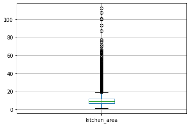

```python
data.boxplot(column='kitchen_area')
```

После 50 мало значений. Верхний ус упирается в 20, приближать не будем.

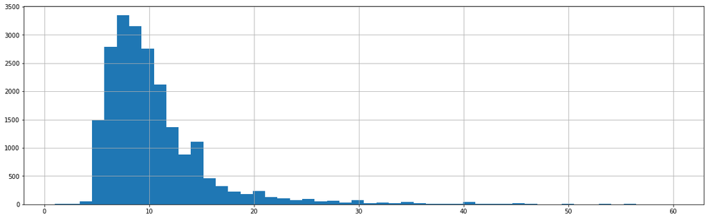

```python
data['kitchen_area'].hist(bins=50, range=(1,60), figsize=(20,6))
```

После 30 квартир мало, после 50 вообще ерунда. До 5 тоже очень мало.

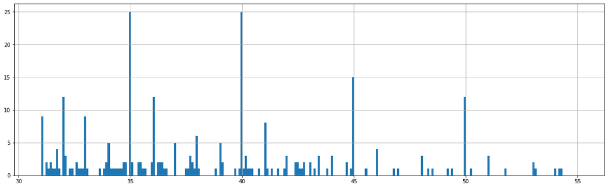

```python
data['kitchen_area'].hist(bins=250, range=(31,55), figsize=(20,6))
```

Бог с ним, оставим всё до 50. Пусть будет.

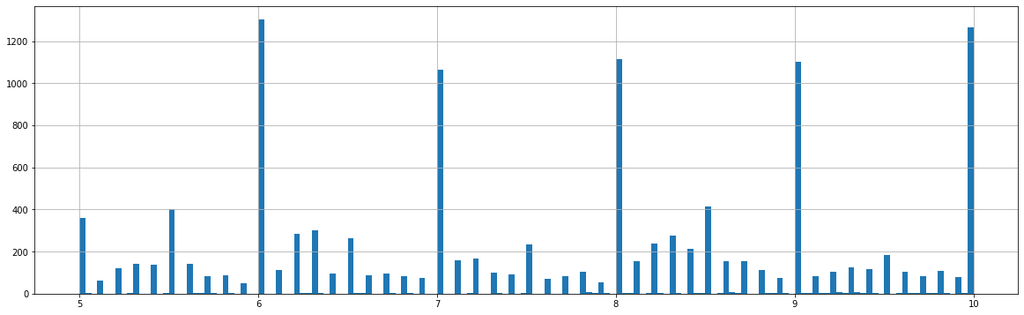

```python
data['kitchen_area'].hist(bins=150, range=(5,10), figsize=(20,6))
```

Люди прутся от целых чисел. Некоторые округляют до 0,5.

```python
data['kitchen_area'].describe()
```

```
count    21421.000000
mean        10.569807
std          5.905438
min          1.300000
25%          7.000000
50%          9.100000
75%         12.000000
max        112.000000
Name: kitchen_area, dtype: float64
```

```python
data[data['kitchen_area'] <= 50]['kitchen_area'].describe()
```

```
count    21375.000000
mean        10.450126
std          5.267284
min          1.300000
25%          7.000000
50%          9.100000
75%         12.000000
max         50.000000
Name: kitchen_area, dtype: float64
```

Не то чтобы стало сильно лучше. Ну, стандотклон пониже стал, славно.

Глянем ещё со строгими ограничениями.

```python
data[(data['kitchen_area'] <= 40) & (data['kitchen_area'] >= 5)]['kitchen_area'].describe()
```

```
count    21185.000000
mean        10.345124
std          4.801582
min          5.000000
25%          7.000000
50%          9.100000
75%         12.000000
max         40.000000
Name: kitchen_area, dtype: float64
```

Ну, стандотклон ещё пониже. Денис, что будет правильным выбрать? Денис сказал оставить до 50.

**Цена объекта**

```python
data['last_price'].describe()
```

```
count    2.369900e+04
mean     6.541549e+06
std      1.088701e+07
min      1.219000e+04
25%      3.400000e+06
50%      4.650000e+06
75%      6.800000e+06
max      7.630000e+08
Name: last_price, dtype: float64
```

Долбаные порядки.

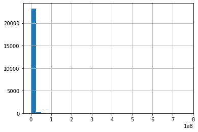

```python
data['last_price'].hist(bins=30)
```

Класс.

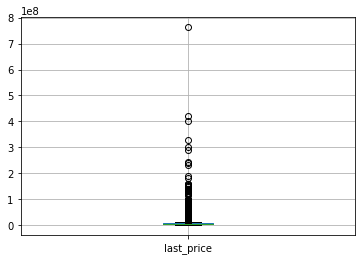

```python
data.boxplot(column='last_price')
```

Ну, после 100кк значений мало. Давайте ещё раз, но с таким ограничением.

```python
data[data['last_price'] > 100000000]['last_price'].count()
```

```
37
```

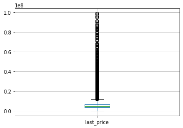

```python
data.query('last_price < 100000000').boxplot(column='last_price')
```

А если оставить только до 50кк.

```python
data[data['last_price'] > 50000000]['last_price'].count()
```

```
131
```

131 строка.

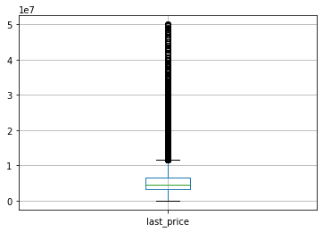

```python
data.query('last_price < 50000000').boxplot(column='last_price')
```

```python
data[data['last_price'] > 30000000]['last_price'].count()
```

```
316
```

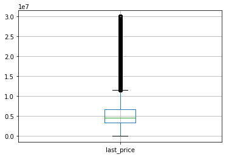

```python
data.query('last_price < 30000000').boxplot(column='last_price')
```

На этом точно стоит остановиться. Вопрос в том, не нужно ли было остановиться раньше.

Поделим всё на лям?

```python
data['price_kk'] = data['last_price'] / 1000000
```

```python
data['price_kk'] = data['price_kk'].round(3)
```

```python
data['price_kk'].describe()
```

```
count    23699.000000
mean         6.541549
std         10.887013
min          0.012000
25%          3.400000
50%          4.650000
75%          6.800000
max        763.000000
Name: price_kk, dtype: float64
```

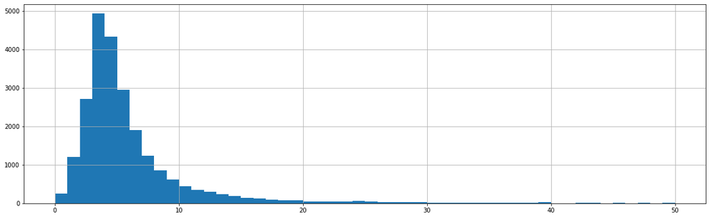

```python
data['price_kk'].hist(bins=50, range=(0.01, 50), figsize=(20,6))
```

Выглядит сносно. Распределение уже похоже на логнормальное. Давайте посмотрим ближе на длинный хвост.

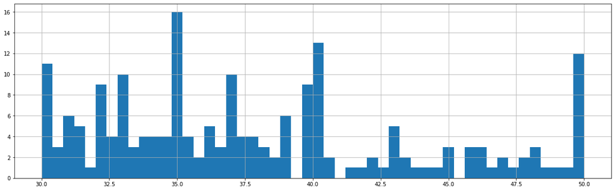

```python
data['price_kk'].hist(bins=50, range=(30, 50), figsize=(20,6))
```

Сложно сказать. Я бы остановился на 40. После 35 ещё есть приличные данные. После 40 уже прям единицы, если не считать пика на 50.

```python
data['price_kk'].describe()
```

```
count    23699.000000
mean         6.541549
std         10.887013
min          0.012000
25%          3.400000
50%          4.650000
75%          6.800000
max        763.000000
Name: price_kk, dtype: float64
```

```python
data[data['price_kk'] < 40]['price_kk'].describe()
```

```
count    23505.000000
mean         5.895151
std          4.551259
min          0.012000
25%          3.400000
50%          4.600000
75%          6.700000
max         39.990000
Name: price_kk, dtype: float64
```

Класс. Медиана снизилась на 0.05, а среднее на 0.65. Это значит, что мы знатно почистили выбросы. Стандотклон уменьшился почти в 2.5 раза. Круто. Хотя разброс всё равно адовый. Стандотклон равен медиане. Среднее больше медианы на треть.

**Итого.** Медиана цены - 4.6кк. Средняя цена 5.9кк. 75% квартир стоят 6.7кк.

**Количество комнат**

```python
data['rooms'].describe()
```

```
count    23699.000000
mean         2.070636
std          1.078405
min          0.000000
25%          1.000000
50%          2.000000
75%          3.000000
max         19.000000
Name: rooms, dtype: float64
```

0 комнат - это сильно. Типо в студии нет комнат, да? Смотрите, зато среднее и медиана почти равно! Это ли не прекрасно. Максимум комнат 19. Солидно.

```python
data[data['rooms'] == 0][['rooms', 'studio', 'last_price', 'total_area', 'living_area', 'kitchen_area']]
```

|  | rooms | studio | last_price | total_area | living_area | kitchen_area |
| --- | --- | --- | --- | --- | --- | --- |
| 144 | 0 | True | 2450000 | 27.00 | 15.50 | NaN |
| 349 | 0 | False | 2320000 | 25.00 | 17.00 | NaN |
| 440 | 0 | True | 2480000 | 27.11 | 24.75 | NaN |
| 508 | 0 | False | 3375000 | 34.40 | 24.30 | NaN |
| 608 | 0 | True | 1850000 | 25.00 | NaN | NaN |
| ... | ... | ... | ... | ... | ... | ... |
| 23210 | 0 | True | 3200000 | 26.00 | 18.00 | NaN |
| 23442 | 0 | False | 2500000 | 27.70 | 18.00 | NaN |
| 23554 | 0 | True | 3350000 | 26.00 | NaN | NaN |
| 23592 | 0 | False | 1450000 | 29.00 | 18.00 | NaN |
| 23637 | 0 | True | 2350000 | 26.00 | 17.00 | NaN |

197 rows × 6 columns

Блин, 197. Придётся кодить.

```python
data.query('rooms == 0').pivot_table(
    index='rooms', values=['studio', 'last_price', 'total_area', 'living_area', 'kitchen_area'],
    aggfunc=['mean'])
```

| rooms | mean last_price | mean living_area | mean studio | mean total_area |
| --- | --- | --- | --- | --- |
| 0 | 3.337724e+06 | 18.865246 | 0.700508 | 29.279746 |

Нужно ли написать позапрошлую строку кода, но, только для НЕ студий?

```python
data[(data['rooms'] == 0) & (data['studio'] == False)][['rooms', 'studio', 'last_price', 'total_area', 'living_area', 'kitchen_area']]
```

|  | rooms | studio | last_price | total_area | living_area | kitchen_area |
| --- | --- | --- | --- | --- | --- | --- |
| 349 | 0 | False | 2320000 | 25.00 | 17.0 | NaN |
| 508 | 0 | False | 3375000 | 34.40 | 24.3 | NaN |
| 780 | 0 | False | 2600000 | 26.10 | NaN | NaN |
| 839 | 0 | False | 1900000 | 35.00 | 15.0 | NaN |
| 946 | 0 | False | 2200000 | 23.00 | 18.0 | NaN |
| 1574 | 0 | False | 2200000 | 22.00 | 15.0 | NaN |
| 1625 | 0 | False | 1980000 | 23.98 | 10.5 | NaN |
| 2532 | 0 | False | 3500000 | 27.10 | 18.7 | NaN |
| 3019 | 0 | False | 2100000 | 24.00 | 18.0 | NaN |
| 4115 | 0 | False | 2600000 | 24.00 | 18.0 | NaN |
| 4437 | 0 | False | 3200000 | 25.00 | 18.6 | NaN |
| 4683 | 0 | False | 3650000 | 35.00 | 23.4 | NaN |
| 4876 | 0 | False | 3000000 | 25.00 | 17.0 | NaN |
| 5749 | 0 | False | 3590000 | 25.00 | NaN | NaN |
| 6472 | 0 | False | 3620000 | 28.00 | 18.0 | NaN |
| 6612 | 0 | False | 3590000 | 26.80 | 19.0 | NaN |
| 6805 | 0 | False | 1850000 | 31.00 | 18.0 | NaN |
| 7008 | 0 | False | 5200000 | 32.30 | 25.5 | NaN |
| 7237 | 0 | False | 2999000 | 42.63 | 25.7 | NaN |
| 7286 | 0 | False | 2580000 | 30.00 | 19.0 | NaN |
| 7818 | 0 | False | 3300000 | 27.30 | NaN | NaN |
| 9412 | 0 | False | 2100000 | 16.00 | 13.0 | NaN |
| 9586 | 0 | False | 1670000 | 28.30 | 18.2 | NaN |
| 9861 | 0 | False | 2350000 | 25.00 | 25.0 | NaN |
| 10284 | 0 | False | 2700000 | 24.00 | 15.5 | NaN |
| 10606 | 0 | False | 2950000 | 25.27 | 25.0 | NaN |
| 11035 | 0 | False | 2500000 | 26.00 | 14.0 | NaN |
| 11051 | 0 | False | 2200000 | 26.00 | 12.0 | NaN |
| 11157 | 0 | False | 2900000 | 27.30 | 20.0 | NaN |
| 11331 | 0 | False | 1315000 | 27.32 | 18.7 | NaN |
| 11692 | 0 | False | 2550000 | 23.06 | 18.0 | NaN |
| 11705 | 0 | False | 3380000 | 26.00 | 17.0 | NaN |
| 12412 | 0 | False | 3300000 | 27.00 | 25.0 | NaN |
| 12691 | 0 | False | 3700000 | 24.20 | 24.2 | NaN |
| 13953 | 0 | False | 3255000 | 28.20 | 20.0 | NaN |
| 15105 | 0 | False | 2500000 | 26.10 | 18.0 | NaN |
| 15273 | 0 | False | 2700000 | 25.20 | 15.2 | NaN |
| 15434 | 0 | False | 2200000 | 27.00 | 15.0 | NaN |
| 16429 | 0 | False | 2460000 | 28.01 | 18.1 | NaN |
| 17695 | 0 | False | 2550000 | 24.00 | 17.0 | NaN |
| 17729 | 0 | False | 2948000 | 28.05 | 21.8 | NaN |
| 17805 | 0 | False | 2600000 | 31.10 | 21.4 | NaN |
| 17824 | 0 | False | 2300000 | 22.50 | 20.0 | NaN |
| 18042 | 0 | False | 2950000 | 25.90 | 16.9 | NaN |
| 18549 | 0 | False | 3699000 | 29.00 | 19.0 | NaN |
| 18782 | 0 | False | 2500000 | 25.00 | 17.0 | NaN |
| 19392 | 0 | False | 71000000 | 371.00 | NaN | NaN |
| 19477 | 0 | False | 2300000 | 20.00 | 16.0 | NaN |
| 19735 | 0 | False | 2800000 | 30.50 | 20.0 | NaN |
| 19917 | 0 | False | 2340000 | 25.41 | 18.5 | NaN |
| 20002 | 0 | False | 2700000 | 28.00 | 20.0 | NaN |
| 20045 | 0 | False | 3100000 | 25.00 | 18.0 | NaN |
| 20054 | 0 | False | 2730000 | 21.00 | 14.0 | NaN |
| 20793 | 0 | False | 3600000 | 27.50 | 19.0 | NaN |
| 21299 | 0 | False | 2450000 | 28.50 | 18.0 | NaN |
| 21628 | 0 | False | 3900000 | 34.00 | 24.0 | NaN |
| 22573 | 0 | False | 2250000 | 24.00 | 15.0 | NaN |
| 23442 | 0 | False | 2500000 | 27.70 | 18.0 | NaN |
| 23592 | 0 | False | 1450000 | 29.00 | 18.0 | NaN |

И что нам теперь делать? Менять почти во всех этих строках False на True? Ясно только, что париться о 0 комнат не нужно, т.к. это студии.

Мне кажется, нужно будет выкинуть квартиры с 0 комнат из этих рассчётов. Но я не уверен.

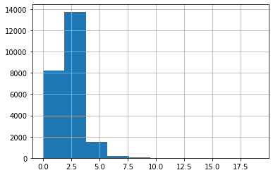

```python
data['rooms'].hist()
```

Мы видим, что у нас почти поровну однушек и двушек - около 8к. Поменьше трёшек - 5,8к где-то. Четырёшек немного больше 1к, пятюшек около 300. А где будем отрезать? Ксати, давайте выведем на экран нормальную статистику.

```python
data.groupby('rooms')['rooms'].count()
```

```
rooms
0      197
1     8047
2     7940
3     5814
4     1180
5      326
6      105
7       59
8       12
9        8
10       3
11       2
12       1
14       2
15       1
16       1
19       1
Name: rooms, dtype: int64
```

7 или 9? Давайте 9.

```python
data['rooms'].describe()
```

```
count    23699.000000
mean         2.070636
std          1.078405
min          0.000000
25%          1.000000
50%          2.000000
75%          3.000000
max         19.000000
Name: rooms, dtype: float64
```

```python
data.loc[data['rooms'] < 10, 'rooms'].describe()
```

```
count    23688.000000
mean         2.065603
std          1.051309
min          0.000000
25%          1.000000
50%          2.000000
75%          3.000000
max          9.000000
Name: rooms, dtype: float64
```

Ну, стало чуть однороднее, но существенной разницы нет, что было ожидаемо. У нас же не было квартиры с тысячей комнат или типо того.

**Высота потолков**

```python
data['ceiling_height'].describe()
```

```
count    14504.000000
mean         2.771499
std          1.261056
min          1.000000
25%          2.520000
50%          2.650000
75%          2.800000
max        100.000000
Name: ceiling_height, dtype: float64
```

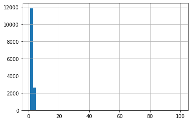

```python
data['ceiling_height'].hist(bins=50)
```

Так, разобраться с этим можно было ещё в предобработке, но сейчас уже точно пора.

```python
data[(data['ceiling_height'] > 9) | (data['ceiling_height'] < 2)]
```

|  | total_images | last_price | total_area | first_day_exposition | rooms | ceiling_height | floors_total | living_area | floor | studio | ... | ponds_around3000 | ponds_nearest | days_exposition | square_cost | weekday | month | year | floor_type | centers_range_km | price_kk |
| --- | --- | --- | --- | --- | --- | --- | --- | --- | --- | --- | --- | --- | --- | --- | --- | --- | --- | --- | --- | --- | --- |
| 355 | 17 | 3600000 | 55.2 | 2018-07-12 | 2 | 25.00 | 5 | 32.0 | 2 | False | ... | NaN | NaN | 259.0 | 65217.39 | четверг | июль | 2018 | другой | -0.0 | 3.600 |
| 3148 | 14 | 2900000 | 75.0 | 2018-11-12 | 3 | 32.00 | 3 | 53.0 | 2 | False | ... | NaN | NaN | NaN | 38666.67 | понедельник | ноябрь | 2018 | другой | -0.0 | 2.900 |
| 4643 | 0 | 4300000 | 45.0 | 2018-02-01 | 2 | 25.00 | 9 | 30.0 | 2 | False | ... | 1.0 | 331.0 | 181.0 | 95555.56 | четверг | февраль | 2018 | другой | 13.0 | 4.300 |
| 4876 | 7 | 3000000 | 25.0 | 2017-09-27 | 0 | 27.00 | 25 | 17.0 | 17 | False | ... | NaN | NaN | 28.0 | 120000.00 | среда | сентябрь | 2017 | другой | -0.0 | 3.000 |
| 5076 | 0 | 3850000 | 30.5 | 2018-10-03 | 1 | 24.00 | 5 | 19.5 | 1 | False | ... | 1.0 | 578.0 | 7.0 | 126229.51 | среда | октябрь | 2018 | первый | 8.0 | 3.850 |
| 5246 | 0 | 2500000 | 54.0 | 2017-10-13 | 2 | 27.00 | 5 | 30.0 | 3 | False | ... | NaN | NaN | 540.0 | 46296.30 | пятница | октябрь | 2017 | другой | -0.0 | 2.500 |
| 5669 | 4 | 4400000 | 50.0 | 2017-08-08 | 2 | 26.00 | 9 | 21.3 | 3 | False | ... | 0.0 | -1.0 | 267.0 | 88000.00 | вторник | август | 2017 | другой | 11.0 | 4.400 |
| 5712 | 5 | 1500000 | 42.8 | 2017-08-14 | 2 | 1.20 | 2 | 27.5 | 1 | False | ... | NaN | NaN | 248.0 | 35046.73 | понедельник | август | 2017 | первый | -0.0 | 1.500 |
| 5807 | 17 | 8150000 | 80.0 | 2019-01-09 | 2 | 27.00 | 36 | 41.0 | 13 | False | ... | 3.0 | 80.0 | 38.0 | 101875.00 | среда | январь | 2019 | другой | 20.0 | 8.150 |
| 6246 | 6 | 3300000 | 44.4 | 2019-03-25 | 2 | 25.00 | 5 | 31.3 | 5 | False | ... | 2.0 | 73.0 | NaN | 74324.32 | понедельник | март | 2019 | последний | 51.0 | 3.300 |
| 9379 | 5 | 3950000 | 42.0 | 2017-03-26 | 3 | 25.00 | 5 | 30.0 | 2 | False | ... | 0.0 | -1.0 | NaN | 94047.62 | воскресенье | март | 2017 | другой | 14.0 | 3.950 |
| 10773 | 8 | 3800000 | 58.0 | 2017-10-13 | 2 | 27.00 | 10 | 30.1 | 3 | False | ... | NaN | NaN | 71.0 | 65517.24 | пятница | октябрь | 2017 | другой | -0.0 | 3.800 |
| 11285 | 0 | 1950000 | 37.0 | 2019-03-20 | 1 | 25.00 | 5 | 17.0 | 4 | False | ... | NaN | NaN | 18.0 | 52702.70 | среда | март | 2019 | другой | -0.0 | 1.950 |
| 14382 | 9 | 1700000 | 35.0 | 2015-12-04 | 1 | 25.00 | 5 | 20.0 | 2 | False | ... | NaN | NaN | 206.0 | 48571.43 | пятница | декабрь | 2015 | другой | -0.0 | 1.700 |
| 15061 | 19 | 5600000 | 56.4 | 2018-05-11 | 2 | 14.00 | 14 | 32.4 | 5 | False | ... | 0.0 | -1.0 | 315.0 | 99290.78 | пятница | май | 2018 | другой | 14.0 | 5.600 |
| 16934 | 5 | 4100000 | 40.0 | 2017-10-17 | 1 | 1.75 | 37 | 17.4 | 5 | False | ... | 3.0 | 80.0 | 71.0 | 102500.00 | вторник | октябрь | 2017 | другой | 20.0 | 4.100 |
| 17496 | 15 | 6700000 | 92.9 | 2019-02-19 | 3 | 20.00 | 17 | 53.2 | 14 | False | ... | 0.0 | -1.0 | NaN | 72120.56 | вторник | февраль | 2019 | другой | 15.0 | 6.700 |
| 17857 | 1 | 3900000 | 56.0 | 2017-12-22 | 3 | 27.00 | 5 | 33.0 | 4 | False | ... | 0.0 | -1.0 | 73.0 | 69642.86 | пятница | декабрь | 2017 | другой | 16.0 | 3.900 |
| 18545 | 6 | 3750000 | 43.0 | 2019-03-18 | 2 | 25.00 | 5 | 29.0 | 3 | False | ... | 0.0 | -1.0 | 12.0 | 87209.30 | понедельник | март | 2019 | другой | 8.0 | 3.750 |
| 20478 | 11 | 8000000 | 45.0 | 2017-07-18 | 1 | 27.00 | 4 | 22.0 | 2 | False | ... | 3.0 | 449.0 | 429.0 | 177777.78 | вторник | июль | 2017 | другой | 3.0 | 8.000 |
| 20507 | 12 | 5950000 | 60.0 | 2018-02-19 | 2 | 22.60 | 14 | 35.0 | 11 | False | ... | 0.0 | -1.0 | 40.0 | 99166.67 | понедельник | февраль | 2018 | другой | 13.0 | 5.950 |
| 21377 | 19 | 4900000 | 42.0 | 2017-04-18 | 1 | 27.50 | 24 | 37.7 | 19 | False | ... | 0.0 | -1.0 | 61.0 | 116666.67 | вторник | апрель | 2017 | другой | 10.0 | 4.900 |
| 21824 | 20 | 2450000 | 44.0 | 2019-02-12 | 2 | 27.00 | 2 | 38.0 | 2 | False | ... | NaN | NaN | NaN | 55681.82 | вторник | февраль | 2019 | последний | -0.0 | 2.450 |
| 22309 | 20 | 5300000 | 45.0 | 2017-09-30 | 1 | 10.30 | 16 | 15.5 | 15 | False | ... | 2.0 | 450.0 | 136.0 | 117777.78 | суббота | сентябрь | 2017 | другой | 12.0 | 5.300 |
| 22336 | 19 | 9999000 | 92.4 | 2019-04-05 | 2 | 32.00 | 6 | 55.5 | 5 | False | ... | 3.0 | 511.0 | NaN | 108214.29 | пятница | апрель | 2019 | другой | 4.0 | 9.999 |
| 22590 | 16 | 6000000 | 55.0 | 2018-10-31 | 2 | 1.00 | 12 | 32.4 | 7 | False | ... | 2.0 | 289.0 | 13.0 | 109090.91 | среда | октябрь | 2018 | другой | 14.0 | 6.000 |
| 22869 | 0 | 15000000 | 25.0 | 2018-07-25 | 1 | 100.00 | 5 | 14.0 | 5 | False | ... | 3.0 | 30.0 | 19.0 | 600000.00 | среда | июль | 2018 | последний | 8.0 | 15.000 |
| 22938 | 14 | 4000000 | 98.0 | 2018-03-15 | 4 | 27.00 | 2 | 73.0 | 2 | False | ... | NaN | NaN | 27.0 | 40816.33 | четверг | март | 2018 | последний | -0.0 | 4.000 |

28 rows × 28 columns

Какие-то явно нужно разделить на 10. Какие-то, кажется, можно исправить вручную (например, 1.75 заменить на 2.75). С какими-то непоятно, что делать (например строка №15061 с высотой 14 метров, в доме с 14 этажами и на 5 этаже или строка №22869 с высотой 100м). Давайте поступим так: всё, что больше 20 и меньше 35 - поделим на 10. Остальное выкинем.

```python
data.loc[(data['ceiling_height'] > 20) & (data['ceiling_height'] < 35), 'ceiling_height'] /= 10
```

```python
data[(data['ceiling_height'] > 20) & (data['ceiling_height'] < 35)]
```

|  | total_images | last_price | total_area | first_day_exposition | rooms | ceiling_height | floors_total | living_area | floor | studio | ... | ponds_around3000 | ponds_nearest | days_exposition | square_cost | weekday | month | year | floor_type | centers_range_km | price_kk |
| --- | --- | --- | --- | --- | --- | --- | --- | --- | --- | --- | --- | --- | --- | --- | --- | --- | --- | --- | --- | --- | --- |

0 rows × 28 columns

Отлично, теперь заменим аномальные значения на -1.

```python
data.loc[(data['ceiling_height'] > 10) | (data['ceiling_height'] < 2), 'ceiling_height'] = -1
```

Снова обратимся к описательной статистике.

```python
data[data['ceiling_height'] > 0]['ceiling_height'].describe()
```

```
count    14497.000000
mean         2.728149
std          0.292435
min          2.000000
25%          2.510000
50%          2.650000
75%          2.800000
max          8.300000
Name: ceiling_height, dtype: float64
```

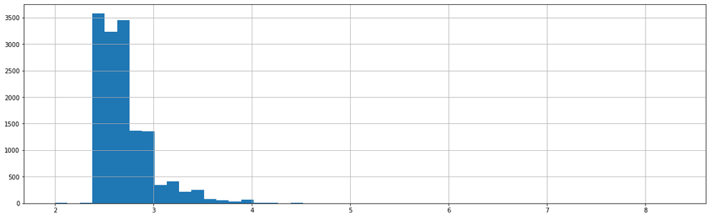

```python
data[data['ceiling_height'] > 0]['ceiling_height'].hist(bins=50, figsize=(20, 6))
```